# Gene-Level DGE Summary: NMD Inhibition Effects

Analysis Pipeline

2026-01-16

# 1 Analysis Overview

This report analyzes **gene-level differential expression** between Smg1i (NMD inhibitor) and DMSO control across 6 lung cell types using short-read RNA sequencing data.

**Research Questions:**

1. How many genes are responsive to NMD inhibition in each cell type?
2. Which genes are the most significant NMD targets?
3. Are NMD-responsive genes consistent across cell types or cell-type-specific?
4. Do NMD-responsive genes have distinct expression characteristics?
5. What biological pathways are enriched among NMD-responsive genes?

**Key Terminology:**

- **NMD-responsive genes:** Genes with positive log fold change (logFC > 0) and adjusted p-value < 0.05, indicating upregulation when NMD is inhibited by Smg1i treatment
- **Gene-level analysis:** Analysis at the gene level (not isoform/transcript level), aggregating all isoforms per gene

# 2 Load Libraries

```r
library(tidyverse)
library(data.table)
library(DT)
library(edgeR)
library(tibble)
library(rlang)
```

# 3 Load Gene-Level DGE Data

```r
# Read gene-level DGE results for each cell type
dge_files <- list.files(INPUT_DGE_DIR, pattern = DGE_FILE_PATTERN, full.names = TRUE)

cat("Loading", length(dge_files), "gene-level DGE result files...\n")
```

```
## Loading 6 gene-level DGE result files...
```

```r
all_gene_dge <- map_df(dge_files, ~{
  df <- read_csv(.x, show_col_types = FALSE)

  # Extract cell type from filename
  basename <- basename(.x)
  parts <- str_split(basename, "_")[[1]]
  celltype <- parts[4]  # nmd_sr_dge_CELLTYPE_date.csv

  df$cell_type_file <- celltype
  df
})

# Map cell type codes to display names
all_gene_dge$cell_type <- CELLTYPE_MAP[all_gene_dge$cell_type_file]

# Filter out any unmapped cell types
all_gene_dge <- all_gene_dge %>% filter(!is.na(cell_type))

# Validate and clean gene symbols
all_gene_dge <- all_gene_dge %>%
  mutate(
    # Mark invalid gene symbols
    valid_symbol = !is.na(hgnc_symbol) & hgnc_symbol != "" & !str_detect(hgnc_symbol, "^ENSG"),
    # For display, use hgnc_symbol if valid, otherwise ensembl_gene_id_version
    gene_display = ifelse(valid_symbol, hgnc_symbol, ensembl_gene_id_version)
  )

cat("Loaded", nrow(all_gene_dge), "gene-level DGE results\n")
```

```
## Loaded 124380 gene-level DGE results
```

```r
cat("Cell types:", paste(unique(all_gene_dge$cell_type), collapse = ", "), "\n")
```

```
## Cell types: AT, DD, DD_ALI, DO, FB, MV
```

```r
cat("Genes per cell type:", n_distinct(all_gene_dge$ensembl_gene_id_version) / n_distinct(all_gene_dge$cell_type), "\n")
```

```
## Genes per cell type: 3455
```

```r
cat("Genes with valid HGNC symbols:", sum(all_gene_dge$valid_symbol),
    "(", round(100 * mean(all_gene_dge$valid_symbol), 1), "%)\n\n")
```

```
## Genes with valid HGNC symbols: 108846 ( 87.5 %)
```

# 4 Summary Statistics

```r
cat("## Overall Summary by Cell Type\n\n")
```

```
## ## Overall Summary by Cell Type
```

```r
# Calculate summary statistics per cell type
summary_stats <- all_gene_dge %>%
  group_by(cell_type) %>%
  summarize(
    n_valid_symbols = sum(valid_symbol),
    n_sig = sum(adj.P.Val < SIGNIFICANCE_THRESHOLD),
    pct_sig = 100 * n_sig / n(),
    n_nmd_responsive = sum(logFC > 0 & adj.P.Val < SIGNIFICANCE_THRESHOLD),
    pct_nmd_responsive = 100 * n_nmd_responsive / n_sig,  # As % of significant genes
    n_nmd_suppressed = sum(logFC < 0 & adj.P.Val < SIGNIFICANCE_THRESHOLD),
    pct_nmd_suppressed = 100 * n_nmd_suppressed / n_sig,  # As % of significant genes
    mean_logFC_responsive = mean(logFC[logFC > 0 & adj.P.Val < SIGNIFICANCE_THRESHOLD]),
    median_logFC_responsive = median(logFC[logFC > 0 & adj.P.Val < SIGNIFICANCE_THRESHOLD]),
    min_logFC = min(logFC),
    max_logFC = max(logFC),
    .groups = "drop"
  )

cat("**Table 1. Gene-level DGE summary statistics by cell type**\n\n")
```

```
## **Table 1. Gene-level DGE summary statistics by cell type**
```

```r
cat("Column definitions:\n")
```

```
## Column definitions:
```

```r
cat("- **n_valid_symbols**: Genes with valid HGNC symbols\n")
```

```
## - **n_valid_symbols**: Genes with valid HGNC symbols
```

```r
cat("- **n_sig**: Significant genes (adj.P.Val < 0.05)\n")
```

```
## - **n_sig**: Significant genes (adj.P.Val < 0.05)
```

```r
cat("- **pct_sig**: Percent of tested genes that are significant\n")
```

```
## - **pct_sig**: Percent of tested genes that are significant
```

```r
cat("- **n_nmd_responsive**: Genes upregulated by Smg1i (logFC > 0, adj.P.Val < 0.05)\n")
```

```
## - **n_nmd_responsive**: Genes upregulated by Smg1i (logFC > 0, adj.P.Val < 0.05)
```

```r
cat("- **pct_nmd_responsive**: Percent of significant genes that are NMD-responsive\n")
```

```
## - **pct_nmd_responsive**: Percent of significant genes that are NMD-responsive
```

```r
cat("- **n_nmd_suppressed**: Genes downregulated by Smg1i (logFC < 0, adj.P.Val < 0.05)\n")
```

```
## - **n_nmd_suppressed**: Genes downregulated by Smg1i (logFC < 0, adj.P.Val < 0.05)
```

```r
cat("- **pct_nmd_suppressed**: Percent of significant genes that are NMD-suppressed\n")
```

```
## - **pct_nmd_suppressed**: Percent of significant genes that are NMD-suppressed
```

```r
cat("- **mean/median_logFC_responsive**: Average fold change for NMD-responsive genes\n\n")
```

```
## - **mean/median_logFC_responsive**: Average fold change for NMD-responsive genes
```

```r
datatable(summary_stats,
          options = list(pageLength = 10, scrollX = TRUE),
          caption = "Table 1. Gene-level DGE summary statistics by cell type") %>%
  formatRound(columns = c("pct_sig", "pct_nmd_responsive", "pct_nmd_suppressed",
                          "mean_logFC_responsive", "median_logFC_responsive",
                          "min_logFC", "max_logFC"),
              digits = 2)
```

|  | cell_type | n_valid_symbols | n_sig | pct_sig | n_nmd_responsive | pct_nmd_responsive | n_nmd_suppressed | pct_nmd_suppressed | mean_logFC_responsive | median_logFC_responsive | min_logFC | max_logFC |
| --- | --- | --- | --- | --- | --- | --- | --- | --- | --- | --- | --- | --- |
| 1 | AT | 18141 | 666 | 3.21273516642547 | 603 | 90.54054054054055 | 63 | 9.45945945945946 | 1.499260364842454 | 1.244 | -6.135 | 6.435 |
| 2 | DD | 18141 | 2954 | 14.24987940183309 | 2085 | 70.58226134055518 | 869 | 29.41773865944482 | 1.375212949640288 | 1.076 | -4.74 | 9.308 |
| 3 | DD_ALI | 18141 | 1 | 0.00482392667631452 | 1 | 100 | 0 | 0 | 1.078 | 1.078 | -5.732 | 6.193 |
| 4 | DO | 18141 | 4 | 0.01929570670525808 | 4 | 100 | 0 | 0 | 1.20175 | 1.1955 | -6.631 | 7.21 |
| 5 | FB | 18141 | 800 | 3.859141341051616 | 573 | 71.625 | 227 | 28.375 | 1.53242757417103 | 1.214 | -7.995 | 9.93 |
| 6 | MV | 18141 | 1748 | 8.432223830197781 | 1198 | 68.53546910755149 | 550 | 31.46453089244851 | 1.544649415692821 | 1.206 | -8.264 | 10.734 |

```r
# Save summary statistics
write_tsv(summary_stats, OUTPUT_SUMMARY)
cat("\nSaved:", OUTPUT_SUMMARY, "\n\n")
```

```
##
## Saved: ../tmp/gene_summary_statistics_2026.1.15.tsv
```

## 4.1 Identify NMD-Responsive Genes

```r
# Define NMD-responsive genes
nmd_responsive_genes <- all_gene_dge %>%
  filter(logFC > 0, adj.P.Val < SIGNIFICANCE_THRESHOLD) %>%
  select(cell_type, ensembl_gene_id_version, hgnc_symbol, gene_display,
         logFC, adj.P.Val, AveExpr, t, B)

cat("Total NMD-responsive genes (across all cell types):", nrow(nmd_responsive_genes), "\n")
```

```
## Total NMD-responsive genes (across all cell types): 4464
```

```r
cat("Unique NMD-responsive genes:", n_distinct(nmd_responsive_genes$ensembl_gene_id_version), "\n\n")
```

```
## Unique NMD-responsive genes: 2491
```

```r
# Summary by cell type
nmd_summary <- nmd_responsive_genes %>%
  group_by(cell_type) %>%
  summarize(
    n_nmd_genes = n(),
    mean_logFC = mean(logFC),
    median_logFC = median(logFC),
    .groups = "drop"
  )

print(nmd_summary)
```

```
## # A tibble: 6 × 4
##   cell_type n_nmd_genes mean_logFC median_logFC
##   <chr>           <int>      <dbl>        <dbl>
## 1 AT                603       1.50         1.24
## 2 DD               2085       1.38         1.08
## 3 DD_ALI              1       1.08         1.08
## 4 DO                  4       1.20         1.20
## 5 FB                573       1.53         1.21
## 6 MV               1198       1.54         1.21
```

```r
cat("\n")
```

# 5 Top NMD-Responsive Genes

```r
cat("## Top", TOP_HITS_N, "NMD-Responsive Genes per Cell Type\n\n")
```

## 5.1 Top 500 NMD-Responsive Genes per Cell Type

```r
# Create top hits tables for each cell type
table_num <- 2  # Start at 2 since Table 1 is summary statistics

for (ct in unique(all_gene_dge$cell_type)) {
  cat("### ", ct, "\n\n")

  top_hits <- nmd_responsive_genes %>%
    filter(cell_type == ct) %>%
    arrange(adj.P.Val) %>%
    head(TOP_HITS_N) %>%
    select(hgnc_symbol, gene_display, logFC, adj.P.Val, AveExpr)

  cat("**Table", table_num, ". Top", TOP_HITS_N, "NMD-Responsive Genes in", ct, "**\n\n")
  cat("Column definitions:\n")
  cat("- **hgnc_symbol**: HGNC gene symbol\n")
  cat("- **gene_display**: Gene name for display (symbol if available, otherwise Ensembl ID)\n")
  cat("- **logFC**: Log2 fold change (Smg1i vs DMSO)\n")
  cat("- **adj.P.Val**: FDR-adjusted p-value\n")
  cat("- **AveExpr**: Average log2 expression\n\n")

  dt <- datatable(
    top_hits,
    options = list(
      pageLength = 10,
      scrollX = TRUE
    ),
    caption = paste0("Table ", table_num, ". Top ", TOP_HITS_N, " NMD-responsive genes in ", ct)
  ) %>%
    formatRound(columns = c("logFC", "AveExpr"), digits = 3)

  print(htmltools::tagList(dt))
  cat("\n\n")

  table_num <- table_num + 1
}
```

### 5.1.1 AT

**Table 2 . Top 500 NMD-Responsive Genes in AT**

Column definitions: - **hgnc_symbol**: HGNC gene symbol - **gene_display**: Gene name for display (symbol if available, otherwise Ensembl ID) - **logFC**: Log2 fold change (Smg1i vs DMSO) - **adj.P.Val**: FDR-adjusted p-value - **AveExpr**: Average log2 expression

|  | hgnc_symbol | gene_display | logFC | adj.P.Val | AveExpr |
| --- | --- | --- | --- | --- | --- |
| 1 | CDKN2AIP | CDKN2AIP | 2.291 | 7.599062478731301e-10 | 5.419 |
| 2 | SMPD4BP | SMPD4BP | 2.849 | 7.599062478731301e-10 | 4.14 |
| 3 | IFRD1 | IFRD1 | 2.819 | 7.599062478731301e-10 | 6.279 |
| 4 |  | ENSG00000291073.1 | 3.349 | 1.13829026469747e-08 | 3.938 |
| 5 | SNHG17 | SNHG17 | 3.077 | 2.97124803981133e-08 | 4.289 |
| 6 | NBPF12 | NBPF12 | 2.499 | 2.97124803981133e-08 | 4.478 |
| 7 | SNHG15 | SNHG15 | 2.714 | 4.1494524348782e-08 | 4.896 |
| 8 | CHASERR | CHASERR | 2.124 | 1.05962215411367e-07 | 6.226 |
| 9 |  | ENSG00000290927.1 | 2.529 | 1.38993608086988e-07 | 3.596 |
| 10 | UBAP2 | UBAP2 | 1.125 | 1.91212383549504e-07 | 6.016 |

[output cut: 490 more lines]

### 5.1.2 DD

**Table 3 . Top 500 NMD-Responsive Genes in DD**

Column definitions: - **hgnc_symbol**: HGNC gene symbol - **gene_display**: Gene name for display (symbol if available, otherwise Ensembl ID) - **logFC**: Log2 fold change (Smg1i vs DMSO) - **adj.P.Val**: FDR-adjusted p-value - **AveExpr**: Average log2 expression

|  | hgnc_symbol | gene_display | logFC | adj.P.Val | AveExpr |
| --- | --- | --- | --- | --- | --- |
| 1 |  | ENSG00000291073.1 | 4.014 | 0 | 3.938 |
| 2 | DCLRE1C | DCLRE1C | 2.661 | 0 | 4.83 |
| 3 | SMPD4BP | SMPD4BP | 2.559 | 0 | 4.14 |
| 4 | UBAP2 | UBAP2 | 1.45 | 0 | 6.016 |
| 5 |  | ENSG00000291228.1 | 3.138 | 0 | 3.594 |
| 6 | CHASERR | CHASERR | 2.9 | 0 | 6.226 |
| 7 | ATF4 | ATF4 | 2.232 | 0 | 8.835 |
| 8 | RSRC2 | RSRC2 | 2.32 | 0 | 6.247 |
| 9 | CEP95 | CEP95 | 2.361 | 0 | 4.512 |
| 10 | IFRD1 | IFRD1 | 2.54 | 0 | 6.279 |

[output cut: 490 more lines]

### 5.1.3 DD_ALI

**Table 4 . Top 500 NMD-Responsive Genes in DD_ALI**

Column definitions: - **hgnc_symbol**: HGNC gene symbol - **gene_display**: Gene name for display (symbol if available, otherwise Ensembl ID) - **logFC**: Log2 fold change (Smg1i vs DMSO) - **adj.P.Val**: FDR-adjusted p-value - **AveExpr**: Average log2 expression

|  | hgnc_symbol | gene_display | logFC | adj.P.Val | AveExpr |
| --- | --- | --- | --- | --- | --- |
| 1 | ATF4 | ATF4 | 1.078 | 0.024 | 8.835 |

### 5.1.4 DO

**Table 5 . Top 500 NMD-Responsive Genes in DO**

Column definitions: - **hgnc_symbol**: HGNC gene symbol - **gene_display**: Gene name for display (symbol if available, otherwise Ensembl ID) - **logFC**: Log2 fold change (Smg1i vs DMSO) - **adj.P.Val**: FDR-adjusted p-value - **AveExpr**: Average log2 expression

|  | hgnc_symbol | gene_display | logFC | adj.P.Val | AveExpr |
| --- | --- | --- | --- | --- | --- |
| 1 | IFRD1 | IFRD1 | 1.383 | 0.0040794960339343 | 6.279 |
| 2 | ATF4 | ATF4 | 1.147 | 0.0040794960339343 | 8.835 |
| 3 | CDKN2AIP | CDKN2AIP | 1.033 | 0.0123246206822239 | 5.419 |
| 4 | RASSF1 | RASSF1 | 1.244 | 0.029042322732493 | 5.434 |

### 5.1.5 FB

**Table 6 . Top 500 NMD-Responsive Genes in FB**

Column definitions: - **hgnc_symbol**: HGNC gene symbol - **gene_display**: Gene name for display (symbol if available, otherwise Ensembl ID) - **logFC**: Log2 fold change (Smg1i vs DMSO) - **adj.P.Val**: FDR-adjusted p-value - **AveExpr**: Average log2 expression

|  | hgnc_symbol | gene_display | logFC | adj.P.Val | AveExpr |
| --- | --- | --- | --- | --- | --- |
| 1 | ATF4 | ATF4 | 2.581 | 9.607171845706959e-11 | 8.835 |
| 2 | SLC7A6OS | SLC7A6OS | 1.704 | 1.60573645295642e-09 | 4.662 |
| 3 | SMPD4BP | SMPD4BP | 2.327 | 9.057950375532121e-09 | 4.14 |
| 4 | NBPF12 | NBPF12 | 2.598 | 1.95544211939734e-08 | 4.478 |
| 5 | WASH7P | WASH7P | 2.558 | 1.95544211939734e-08 | 3.37 |
| 6 | CDKN2AIP | CDKN2AIP | 1.753 | 1.97946981361237e-08 | 5.419 |
| 7 | STX1A | STX1A | 2.829 | 5.05901627454878e-08 | 4.02 |
| 8 | SNHG15 | SNHG15 | 2.285 | 9.53451074981554e-08 | 4.896 |
| 9 | NAPB | NAPB | 1.579 | 2.84934413932185e-07 | 4.044 |
| 10 |  | ENSG00000291073.1 | 2.577 | 4.20032559266403e-07 | 3.938 |

[output cut: 490 more lines]

### 5.1.6 MV

**Table 7 . Top 500 NMD-Responsive Genes in MV**

Column definitions: - **hgnc_symbol**: HGNC gene symbol - **gene_display**: Gene name for display (symbol if available, otherwise Ensembl ID) - **logFC**: Log2 fold change (Smg1i vs DMSO) - **adj.P.Val**: FDR-adjusted p-value - **AveExpr**: Average log2 expression

|  | hgnc_symbol | gene_display | logFC | adj.P.Val | AveExpr |
| --- | --- | --- | --- | --- | --- |
| 1 | SMPD4BP | SMPD4BP | 2.823 | 2.10922592527437e-12 | 4.14 |
| 2 | SLC7A6OS | SLC7A6OS | 2.119 | 2.10922592527437e-12 | 4.662 |
| 3 |  | ENSG00000291073.1 | 4.061 | 4.37124637545911e-12 | 3.938 |
| 4 | ATF4 | ATF4 | 2.752 | 4.37124637545911e-12 | 8.835 |
| 5 | ILKAP | ILKAP | 1.888 | 2.28514395700391e-11 | 4.875 |
| 6 | STX1A | STX1A | 3.768 | 7.052772288306679e-11 | 4.02 |
| 7 | SNHG17 | SNHG17 | 3.222 | 8.6154463186813e-11 | 4.289 |
| 8 | RASSF1 | RASSF1 | 2.601 | 1.08421525246776e-10 | 5.434 |
| 9 | IFRD1 | IFRD1 | 2.587 | 1.39279784719898e-10 | 6.279 |
| 10 | SNHG15 | SNHG15 | 2.957 | 1.72652495319818e-10 | 4.896 |

[output cut: 490 more lines]

```r
# Save combined top hits
write_tsv(nmd_responsive_genes, OUTPUT_TOP_HITS)
cat("\nSaved all NMD-responsive genes:", OUTPUT_TOP_HITS, "\n\n")
```

Saved all NMD-responsive genes: ../tmp/gene_top_nmd_responsive_2026.1.15.tsv

# 6 Visualizations

## 6.1 Volcano Plots

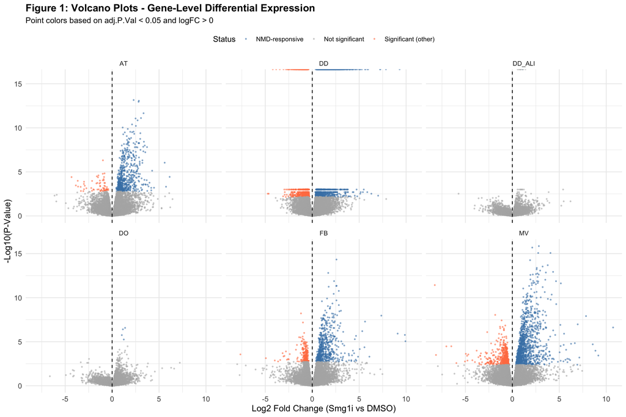

```r
# Prepare data for volcano plot
volcano_data <- all_gene_dge %>%
  mutate(
    neg_log10_pval = -log10(P.Value),
    is_nmd_responsive = logFC > 0 & adj.P.Val < SIGNIFICANCE_THRESHOLD,
    significance = case_when(
      is_nmd_responsive ~ "NMD-responsive",
      adj.P.Val < SIGNIFICANCE_THRESHOLD ~ "Significant (other)",
      TRUE ~ "Not significant"
    )
  )

# Volcano plot
ggplot(volcano_data, aes(x = logFC, y = neg_log10_pval, color = significance)) +
  geom_point(alpha = 0.5, size = 0.5) +
  facet_wrap(~cell_type, ncol = 3) +
  scale_color_manual(values = c(
    "NMD-responsive" = "steelblue",
    "Significant (other)" = "coral",
    "Not significant" = "gray70"
  )) +
  geom_vline(xintercept = 0, linetype = "dashed", color = "black") +
  labs(
    title = "Figure 1: Volcano Plots - Gene-Level Differential Expression",
    subtitle = "Point colors based on adj.P.Val < 0.05 and logFC > 0",
    x = "Log2 Fold Change (Smg1i vs DMSO)",
    y = "-Log10(P-Value)",
    color = "Status"
  ) +
  theme_minimal() +
  theme(
    legend.position = "top",
    axis.text = element_text(size = 10),
    axis.title = element_text(size = 12),
    plot.title = element_text(size = 14, face = "bold")
  )
```

## 6.2 MA Plots

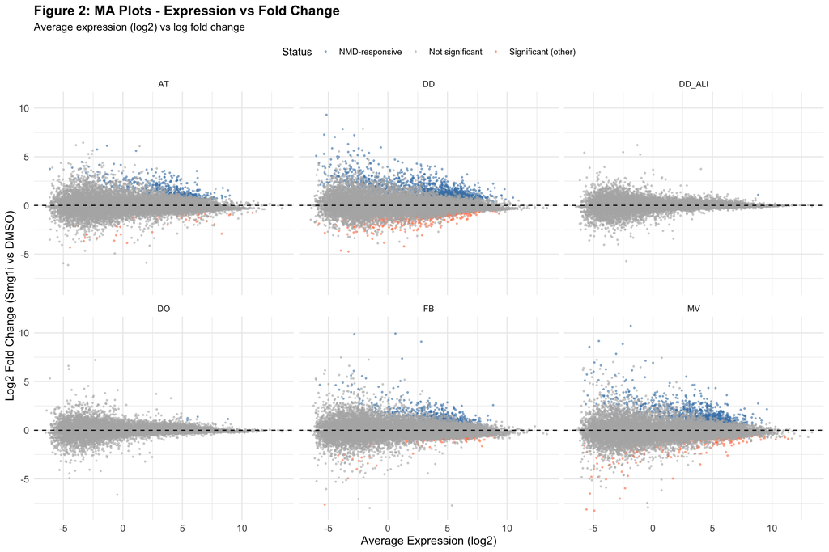

```r
# MA plot
ggplot(volcano_data, aes(x = AveExpr, y = logFC, color = significance)) +
  geom_point(alpha = 0.5, size = 0.5) +
  facet_wrap(~cell_type, ncol = 3) +
  scale_color_manual(values = c(
    "NMD-responsive" = "steelblue",
    "Significant (other)" = "coral",
    "Not significant" = "gray70"
  )) +
  geom_hline(yintercept = 0, linetype = "dashed", color = "black") +
  labs(
    title = "Figure 2: MA Plots - Expression vs Fold Change",
    subtitle = "Average expression (log2) vs log fold change",
    x = "Average Expression (log2)",
    y = "Log2 Fold Change (Smg1i vs DMSO)",
    color = "Status"
  ) +
  theme_minimal() +
  theme(
    legend.position = "top",
    axis.text = element_text(size = 10),
    axis.title = element_text(size = 12),
    plot.title = element_text(size = 14, face = "bold")
  )
```

## 6.3 LogFC Distribution

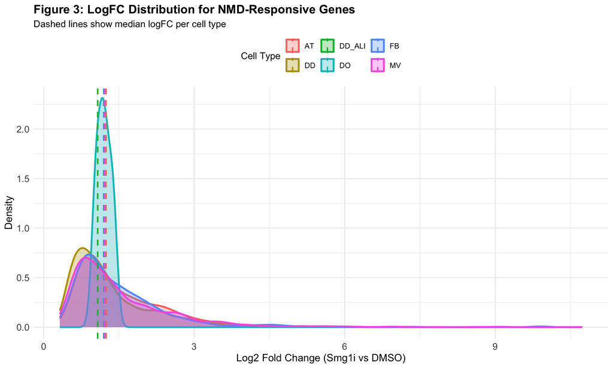

```r
# Calculate median logFC for each cell type
median_logfc <- nmd_responsive_genes %>%
  group_by(cell_type) %>%
  summarize(median_logFC = median(logFC), .groups = "drop")

# Density plot
ggplot(nmd_responsive_genes, aes(x = logFC, fill = cell_type, color = cell_type)) +
  geom_density(alpha = 0.3, linewidth = 1) +
  geom_vline(data = median_logfc, aes(xintercept = median_logFC, color = cell_type),
             linetype = "dashed", linewidth = 0.8) +
  labs(
    title = "Figure 3: LogFC Distribution for NMD-Responsive Genes",
    subtitle = "Dashed lines show median logFC per cell type",
    x = "Log2 Fold Change (Smg1i vs DMSO)",
    y = "Density",
    fill = "Cell Type",
    color = "Cell Type"
  ) +
  theme_minimal() +
  theme(
    legend.position = "top",
    axis.text = element_text(size = 11),
    axis.title = element_text(size = 12),
    plot.title = element_text(size = 14, face = "bold")
  )
```

# 7 Cell-Type Comparison Analysis

## 7.1 Overlap Analysis

```r
cat("## Identifying genes responsive across multiple cell types\n\n")
```

```
## ## Identifying genes responsive across multiple cell types
```

```r
# Count how many cell types each gene is NMD-responsive in
gene_celltype_counts <- nmd_responsive_genes %>%
  group_by(ensembl_gene_id_version, hgnc_symbol, gene_display) %>%
  summarize(
    n_celltypes = n_distinct(cell_type),
    celltypes = paste(sort(unique(cell_type)), collapse = ", "),
    mean_logFC = mean(logFC),
    .groups = "drop"
  ) %>%
  arrange(desc(n_celltypes), desc(mean_logFC))

# Summary of overlap
overlap_summary <- gene_celltype_counts %>%
  count(n_celltypes, name = "n_genes") %>%
  mutate(pct_genes = 100 * n_genes / sum(n_genes))

cat("**Table 8. Genes by number of cell types with NMD response**\n\n")
```

```
## **Table 8. Genes by number of cell types with NMD response**
```

```r
print(overlap_summary)
```

```
## # A tibble: 6 × 3
##   n_celltypes n_genes pct_genes
##         <int>   <int>     <dbl>
## 1           1    1378   55.3
## 2           2     541   21.7
## 3           3     289   11.6
## 4           4     279   11.2
## 5           5       3    0.120
## 6           6       1    0.0401
```

```r
cat("\n")
```

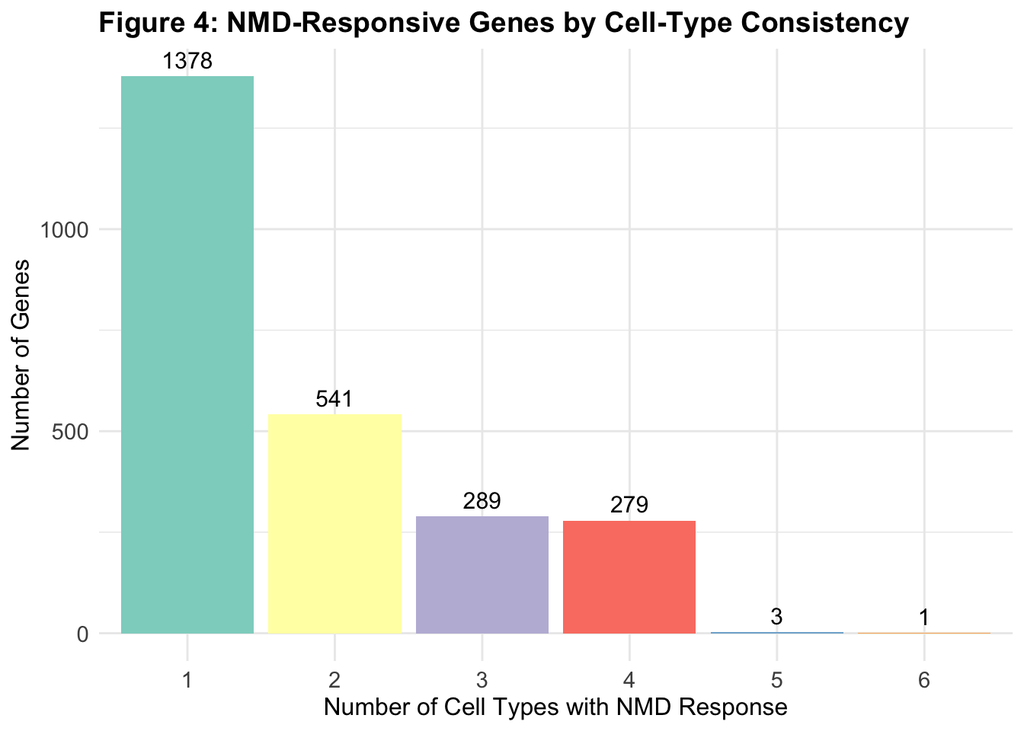

```r
# Visualization
ggplot(overlap_summary, aes(x = factor(n_celltypes), y = n_genes, fill = factor(n_celltypes))) +
  geom_col() +
  geom_text(aes(label = n_genes), vjust = -0.5, size = 4) +
  scale_fill_brewer(palette = "Set3") +
  labs(
    title = "Figure 4: NMD-Responsive Genes by Cell-Type Consistency",
    x = "Number of Cell Types with NMD Response",
    y = "Number of Genes",
    fill = "Cell Types"
  ) +
  theme_minimal() +
  theme(
    legend.position = "none",
    axis.text = element_text(size = 11),
    axis.title = element_text(size = 12),
    plot.title = element_text(size = 14, face = "bold")
  )
```

```r
# Save overlap data
write_tsv(gene_celltype_counts, OUTPUT_CELLTYPE_OVERLAP)
cat("\nSaved:", OUTPUT_CELLTYPE_OVERLAP, "\n\n")
```

```
##
## Saved: ../tmp/gene_celltype_overlap_2026.1.15.tsv
```

## 7.2 NMD-Responsive Genes in Multiple Cell Types

```r
cat("## NMD-Responsive Genes Present in 2 or More Cell Types\n\n")
```

```
## ## NMD-Responsive Genes Present in 2 or More Cell Types
```

```r
# Filter for genes in 2+ cell types
multi_celltype_genes <- gene_celltype_counts %>%
  filter(n_celltypes >= 2) %>%
  arrange(desc(n_celltypes), desc(mean_logFC))

cat("Genes present in 2+ cell types:", nrow(multi_celltype_genes), "\n\n")
```

```
## Genes present in 2+ cell types: 1113
```

```r
if (nrow(multi_celltype_genes) > 0) {
  # Get logFC values for these genes across specified cell types
  # Include only: AT, DD, FB, MV (exclude DO and DD_ALI)
  selected_celltypes <- c("AT", "DD", "FB", "MV")

  # Get logFC values for genes that are NMD-responsive in at least one of the selected cell types
  multi_celltype_wide <- nmd_responsive_genes %>%
    filter(cell_type %in% selected_celltypes) %>%
    semi_join(multi_celltype_genes, by = "ensembl_gene_id_version") %>%
    select(ensembl_gene_id_version, gene_display, cell_type, logFC) %>%
    pivot_wider(
      id_cols = c(ensembl_gene_id_version, gene_display),
      names_from = cell_type,
      values_from = logFC,
      values_fill = NA,
      names_prefix = "logFC_"
    ) %>%
    # Add n_celltypes column by joining with the counts
    left_join(
      gene_celltype_counts %>% select(ensembl_gene_id_version, n_celltypes),
      by = "ensembl_gene_id_version"
    ) %>%
    # Remove ensembl ID and reorder columns: gene_display, n_celltypes, then logFC columns
    select(gene_display, n_celltypes, starts_with("logFC_")) %>%
    # Only keep genes that have at least one logFC value (are responsive in at least one selected cell type)
    filter(if_any(starts_with("logFC_"), ~!is.na(.))) %>%
    arrange(desc(n_celltypes))

  # Save to file first
  output_multi_celltype <- file.path(OUTPUT_DIR, "gene_multi_celltype_nmd_2026.1.15.tsv")
  write_tsv(multi_celltype_wide, output_multi_celltype)
  cat("Saved:", output_multi_celltype, "\n\n")

  # Display in interactive table
  cat("**Table 8A. NMD-Responsive Genes in 2+ Cell Types**\n\n")
  cat("Column definitions:\n")
  cat("- **gene_display**: Gene symbol (HGNC) or Ensembl ID\n")
  cat("- **n_celltypes**: Number of cell types where gene is NMD-responsive\n")
  cat("- **logFC_AT**, **logFC_DD**, **logFC_FB**, **logFC_MV**: Log2 fold change in each cell type (NA if not responsive)\n\n")

  # Determine which logFC columns actually exist in the data
  logfc_cols <- colnames(multi_celltype_wide)[grepl("^logFC_", colnames(multi_celltype_wide))]

  # This must be the last expression in the block to render properly
  datatable(
    multi_celltype_wide,
    options = list(
      pageLength = 25,
      scrollX = TRUE
    ),
    caption = "Table 8A. NMD-responsive genes present in 2 or more cell types"
  ) %>%
    formatRound(columns = logfc_cols, digits = 2)
}
```

```
## Saved: ../tmp/gene_multi_celltype_nmd_2026.1.15.tsv
##
## **Table 8A. NMD-Responsive Genes in 2+ Cell Types**
##
## Column definitions:
## - **gene_display**: Gene symbol (HGNC) or Ensembl ID
## - **n_celltypes**: Number of cell types where gene is NMD-responsive
## - **logFC_AT**, **logFC_DD**, **logFC_FB**, **logFC_MV**: Log2 fold change in each cell type (NA if not responsive)
```

|  | gene_display | n_celltypes | logFC_AT | logFC_DD | logFC_FB | logFC_MV |
| --- | --- | --- | --- | --- | --- | --- |
| 1 | ATF4 | 6 | 1.559 | 2.232 | 2.581 | 2.752 |
| 2 | CDKN2AIP | 5 | 2.291 | 1.782 | 1.753 | 1.607 |
| 3 | IFRD1 | 5 | 2.819 | 2.54 | 1.064 | 2.587 |
| 4 | RASSF1 | 5 | 1.781 | 1.263 | 1.666 | 2.601 |
| 5 | SMPD4BP | 4 | 2.849 | 2.559 | 2.327 | 2.823 |
| 6 | ENSG00000291073.1 | 4 | 3.349 | 4.014 | 2.577 | 4.061 |
| 7 | SNHG17 | 4 | 3.077 | 2.796 | 2.151 | 3.222 |
| 8 | NBPF12 | 4 | 2.499 | 2.489 | 2.598 | 2.51 |
| 9 | SNHG15 | 4 | 2.714 | 2.971 | 2.285 | 2.957 |
| 10 | CHASERR | 4 | 2.124 | 2.9 | 1.495 | 2.671 |

[output cut: 1103 more lines]

## 7.3 Core NMD Targets

```r
cat("## Genes responsive in >= 4 cell types (Core NMD targets)\n\n")
```

```
## ## Genes responsive in >= 4 cell types (Core NMD targets)
```

```r
# Identify core targets (responsive in at least 4 cell types)
core_targets <- gene_celltype_counts %>%
  filter(n_celltypes >= 4) %>%
  arrange(desc(n_celltypes), desc(mean_logFC))

cat("Core NMD targets (≥4 cell types):", nrow(core_targets), "genes\n\n")
```

```
## Core NMD targets (≥4 cell types): 283 genes
```

[output not shown]

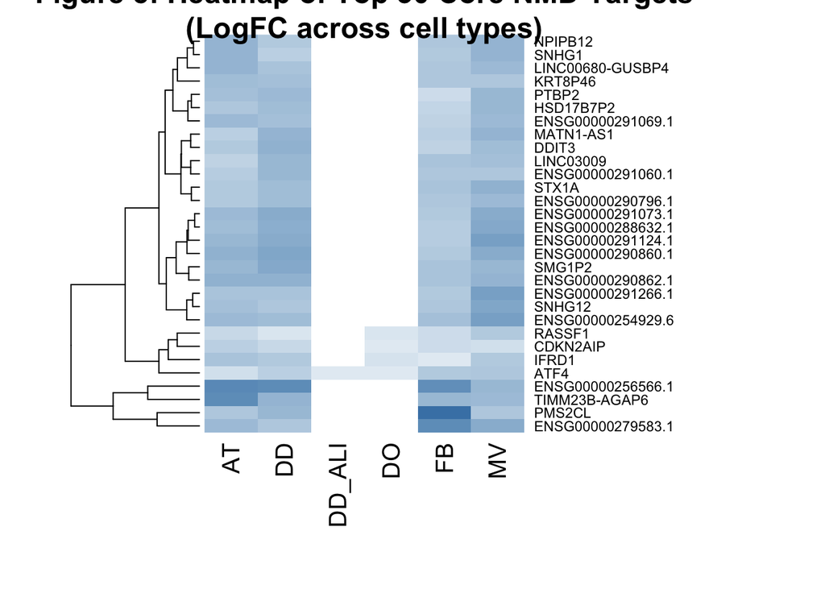

```
##
## Saved: ../tmp/gene_core_nmd_targets_2026.1.15.tsv
```

```r
if (nrow(core_targets) > 0) {
  # Get logFC values for core targets across all cell types
  core_targets_wide <- nmd_responsive_genes %>%
    semi_join(core_targets, by = "ensembl_gene_id_version") %>%
    select(gene_display, cell_type, logFC) %>%
    pivot_wider(names_from = cell_type, values_from = logFC, values_fill = NA)

  # Display top 50
  cat("**Table 9. Top 50 Core NMD Targets**\n\n")
  datatable(
    core_targets_wide %>% head(50),
    options = list(pageLength = 10, scrollX = TRUE),
    caption = "Table 9. Core NMD targets with logFC values across cell types"
  ) %>%
    formatRound(columns = 2:ncol(core_targets_wide), digits = 2)

  # Heatmap of top 30 core targets
  if (nrow(core_targets) >= 30) {
    top_core <- core_targets %>% head(30) %>% pull(ensembl_gene_id_version)

    heatmap_data <- nmd_responsive_genes %>%
      filter(ensembl_gene_id_version %in% top_core) %>%
      # Prioritize HGNC symbol, fall back to gene_display if not available
      mutate(display_name = ifelse(!is.na(hgnc_symbol) & hgnc_symbol != "", hgnc_symbol, gene_display)) %>%
      select(display_name, cell_type, logFC) %>%
      pivot_wider(names_from = cell_type, values_from = logFC, values_fill = 0) %>%
      column_to_rownames("display_name") %>%
      as.matrix()

    # Simple heatmap using base graphics
    heatmap(heatmap_data,
            Colv = NA,  # Don't cluster columns
            scale = "none",
            col = colorRampPalette(c("white", "steelblue"))(50),
            margins = c(8, 12),
            main = "Figure 5: Heatmap of Top 30 Core NMD Targets\n(LogFC across cell types)")
  }

  # Save core targets
  write_tsv(core_targets_wide, OUTPUT_CORE_TARGETS)
  cat("\nSaved:", OUTPUT_CORE_TARGETS, "\n\n")
} else {
  cat("No genes found in ≥4 cell types\n\n")
}
```

## 7.4 Cell-Type Specific Genes

```r
cat("## Genes responsive in only 1 cell type (Cell-type specific)\n\n")
```

```
## ## Genes responsive in only 1 cell type (Cell-type specific)
```

```r
# Identify cell-type specific genes
celltype_specific <- gene_celltype_counts %>%
  filter(n_celltypes == 1) %>%
  # Join back to get cell type info
  left_join(
    nmd_responsive_genes %>% select(ensembl_gene_id_version, cell_type, logFC, adj.P.Val),
    by = "ensembl_gene_id_version"
  ) %>%
  arrange(cell_type, desc(logFC))

cat("Cell-type specific genes:", nrow(celltype_specific), "genes\n\n")
```

```
## Cell-type specific genes: 1378 genes
```

```r
# Summary by cell type
specific_summary <- celltype_specific %>%
  group_by(cell_type) %>%
  summarize(
    n_genes = n(),
    mean_logFC_specific = mean(logFC),
    median_logFC_specific = median(logFC),
    .groups = "drop"
  )

cat("**Table 10. Cell-type specific NMD-responsive genes**\n\n")
```

```
## **Table 10. Cell-type specific NMD-responsive genes**
```

```r
print(specific_summary)
```

```
## # A tibble: 4 × 4
##   cell_type n_genes mean_logFC_specific median_logFC_specific
##   <chr>       <int>               <dbl>                 <dbl>
## 1 AT             51                1.59                 1.21
## 2 DD           1047                1.31                 0.952
## 3 FB             59                1.52                 0.998
## 4 MV            221                1.80                 1.25
```

```r
cat("\n")
```

```r
if (nrow(celltype_specific) > 0) {
  # Display top 10 per cell type
  cat("**Top 10 cell-type specific genes per cell type:**\n\n")

  for (ct in unique(all_gene_dge$cell_type)) {
    ct_specific <- celltype_specific %>%
      filter(cell_type == ct) %>%
      select(gene_display, logFC, adj.P.Val) %>%
      head(10)

    if (nrow(ct_specific) > 0) {
      cat("**", ct, "**\n")
      print(knitr::kable(ct_specific, digits = 3))
      cat("\n")
    }
  }

  # Save cell-type specific genes
  write_tsv(celltype_specific, OUTPUT_CELLTYPE_SPECIFIC)
  cat("\nSaved:", OUTPUT_CELLTYPE_SPECIFIC, "\n\n")
}
```

```
## **Top 10 cell-type specific genes per cell type:**
##
## ** AT **
##
##
## |gene_display      | logFC| adj.P.Val|
## |:-----------------|-----:|---------:|
## |ENSG00000285942.1 | 4.464|     0.026|
## |ENSG00000288683.1 | 4.164|     0.027|
## |ENSG00000249685.1 | 3.982|     0.010|
## |CHIAP2            | 3.745|     0.047|
## |ENSG00000291232.1 | 3.141|     0.041|
## |ENSG00000267127.7 | 3.075|     0.027|
## |ENSG00000276490.1 | 2.891|     0.049|
## |ENSG00000293167.1 | 2.878|     0.008|
## |GFI1              | 2.811|     0.007|
## |ENSG00000283251.2 | 2.616|     0.004|
##
## ** DD **
##
##
## |gene_display      | logFC| adj.P.Val|
## |:-----------------|-----:|---------:|
## |KRT16P3           | 9.308|     0.000|
## |KRT16P1           | 7.263|     0.000|
## |PRKY              | 7.021|     0.036|
## |PDXDC2P           | 6.297|     0.023|
## |NPHP3-ACAD11      | 5.960|     0.004|
## |BPTFP1            | 5.876|     0.006|
## |ENSG00000237188.5 | 5.864|     0.017|
## |ENSG00000291262.1 | 5.491|     0.009|
## |ENSG00000255872.3 | 5.397|     0.019|
## |AHSA2P            | 5.298|     0.005|
##
## ** FB **
##
##
## |gene_display      | logFC| adj.P.Val|
## |:-----------------|-----:|---------:|
## |ENSG00000258465.8 | 9.930|     0.001|
```

[output cut: 13 more lines]

```
## |gene_display      |  logFC| adj.P.Val|
## |:-----------------|------:|---------:|
## |KPNA2P3           | 10.734|     0.000|
## |ANAPC1P2          |  9.161|     0.009|
## |PGM5P2            |  8.563|     0.001|
## |ENSG00000289346.1 |  7.137|     0.013|
## |ENSG00000290383.1 |  6.919|     0.049|
## |ENSG00000273088.2 |  6.254|     0.001|
## |NPIPA3            |  6.154|     0.021|
## |GUSBP15           |  6.024|     0.017|
## |RNA5-8SN4         |  5.869|     0.031|
## |GPAA1P1           |  5.728|     0.003|
##
##
## Saved: ../tmp/gene_celltype_specific_2026.1.15.tsv
```

# 8 Gene Characteristics Analysis

## 8.1 Expression Level Distribution

We need condition-specific expression data. Let’s load the DGEList to get per-sample expression values.

```r
cat("## Loading DGEList for condition-specific expression\n\n")
```

```
## ## Loading DGEList for condition-specific expression
```

```r
# Load the gene-level DGEList (if available)
DGELIST_PATH <- file.path("..", "results", "rds", "dge_gene_2026.1.3.rds")

if (file.exists(DGELIST_PATH)) {
  dge_gene <- readRDS(DGELIST_PATH)

  # Extract normalized CPM
  cpm_normalized <- cpm(dge_gene, normalized = TRUE, log = FALSE)

  # Check what columns exist in samples metadata
  cat("DGEList samples columns:", paste(colnames(dge_gene$samples), collapse = ", "), "\n")

  # Get sample metadata - adapt to actual column names
  sample_metadata <- dge_gene$samples

  # The CPM matrix column names match the rownames of dge_gene$samples
  # We need to use rownames as the join key, not the sample_id column (which contains donor IDs)
  sample_metadata <- sample_metadata %>%
    rownames_to_column("sample_name")  # Use sample_name for the long sample identifier

  # Check if we have treatment/condition info
  if ("treatment" %in% colnames(sample_metadata) && "ct" %in% colnames(sample_metadata)) {
    # Use the ct column and map to match DGE results
    sample_metadata <- sample_metadata %>%
      select(sample_name, treatment, ct) %>%
      mutate(
        # Map DGEList cell types to match the CELLTYPE_MAP used in DGE loading
        cell_type = case_when(
          ct == "AT2" ~ "AT",        # AT2 in DGEList -> AT in DGE results
          ct == "DO_ALI" ~ "DO",     # DO_ALI in DGEList -> DO in DGE results
          TRUE ~ ct                   # DD, DD_ALI, FB, MV match directly
        )
      ) %>%
      select(-ct)
  } else if ("group" %in% colnames(sample_metadata)) {
    # Try to extract from group column (might be formatted as celltype_treatment)
    cat("Extracting treatment and cell type from 'group' column\n")
    sample_metadata <- sample_metadata %>%
      select(sample_name, group) %>%
      mutate(
        # Try to parse group name (e.g., "AT_DMSO", "DD_Smg1i")
        cell_type = str_extract(group, "^[^_]+"),
        treatment = str_extract(group, "[^_]+$")
      ) %>%
      select(sample_name, treatment, cell_type)
  } else {
    cat("Could not find treatment/cell type information in DGEList\n")
    has_condition_data <- FALSE
  }

  if (exists("sample_metadata")) {
    # Convert to long format with sample metadata
    # The colnames of the CPM matrix match the rownames of dge_gene$samples
    cpm_long <- as.data.frame(cpm_normalized) %>%
      mutate(dgelist_gene_id = rownames(.)) %>%
      pivot_longer(cols = -dgelist_gene_id, names_to = "sample_name", values_to = "cpm") %>%
      left_join(sample_metadata, by = "sample_name")

    # Add gene information from DGEList
    # Check what columns exist in dge_gene$genes
    cat("DGEList genes columns:", paste(colnames(dge_gene$genes), collapse = ", "), "\n")

    gene_info <- dge_gene$genes %>%
      rownames_to_column("dgelist_gene_id")

    # Try to find the Ensembl ID column
    ensembl_col <- NULL
    if ("ensembl_gene_id_version" %in% colnames(gene_info)) {
      ensembl_col <- "ensembl_gene_id_version"
    } else if ("ensembl_gene_id" %in% colnames(gene_info)) {
      ensembl_col <- "ensembl_gene_id"
    } else if ("gene_id" %in% colnames(gene_info)) {
      ensembl_col <- "gene_id"
    }

    if (!is.null(ensembl_col)) {
      cat("Using", ensembl_col, "as the gene identifier\n")
      gene_info <- gene_info %>%
        select(dgelist_gene_id, !!sym(ensembl_col), hgnc_symbol)
    } else {
      cat("WARNING: Could not find Ensembl gene ID column in DGEList\n")
      gene_info <- gene_info %>%
        select(dgelist_gene_id, hgnc_symbol)
    }

    cpm_long <- cpm_long %>%
      left_join(gene_info, by = "dgelist_gene_id")

    cat("Loaded per-sample expression data\n")
    cat("Samples:", n_distinct(cpm_long$sample_name), "\n")

    # Check what gene ID column we have
    if (!is.null(ensembl_col)) {
      cat("Genes:", n_distinct(cpm_long[[ensembl_col]]), "\n")
      cat("Gene identifier column:", ensembl_col, "\n")
    } else {
      cat("Using hgnc_symbol as gene identifier\n")
    }

    cat("Treatments:", paste(unique(cpm_long$treatment), collapse = ", "), "\n")
    cat("Cell types:", paste(unique(cpm_long$cell_type), collapse = ", "), "\n\n")

    has_condition_data <- TRUE
    # Store ensembl_col for later use
    gene_id_column <- ensembl_col
  }
} else {
  cat("DGEList file not found, using AveExpr from DGE results\n\n")
  has_condition_data <- FALSE
  gene_id_column <- NULL
}
```

```
## DGEList samples columns: group, lib.size, norm.factors, sample_id, ct, treatment, cell_type, bam, name
## DGEList genes columns: ensembl_gene_id_version, hgnc_symbol, external_gene_name
## Using ensembl_gene_id_version as the gene identifier
## Loaded per-sample expression data
## Samples: 38
## Genes: 20730
## Gene identifier column: ensembl_gene_id_version
## Treatments: Smg1i, DMSO
## Cell types: MV, FB, DD_ALI, DO, DD, AT
```

### 8.1.1 Expression Distribution in DMSO

```
## Gene expression by condition:
## - Cell types: AT, DD, DD_ALI, DO, FB, MV
## - Treatments: DMSO, Smg1i
##
## NMD-responsive genes cell types: AT, DD, DD_ALI, DO, FB, MV
##
## DMSO expression data rows: 119544
## NMD-responsive genes in DMSO: 4434
```

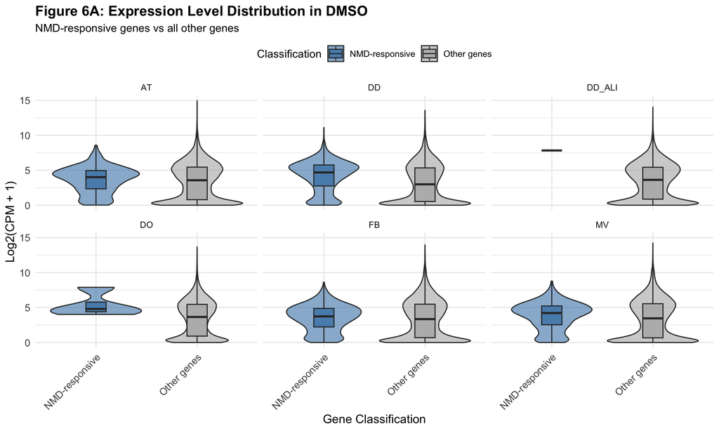

```r
if (has_condition_data) {
  # Calculate mean expression per gene per treatment per cell type
  if (!is.null(gene_id_column)) {
    gene_expr_by_condition <- cpm_long %>%
      filter(!is.na(treatment), !is.na(cell_type)) %>%
      group_by(cell_type, treatment, !!sym(gene_id_column), hgnc_symbol) %>%
      summarize(mean_cpm = mean(cpm), .groups = "drop") %>%
      rename(gene_id = !!sym(gene_id_column))
  } else {
    # If no Ensembl ID, just use hgnc_symbol
    gene_expr_by_condition <- cpm_long %>%
      filter(!is.na(treatment), !is.na(cell_type)) %>%
      group_by(cell_type, treatment, hgnc_symbol) %>%
      summarize(mean_cpm = mean(cpm), .groups = "drop") %>%
      mutate(gene_id = hgnc_symbol)
  }

  cat("Gene expression by condition:\n")
  cat("- Cell types:", paste(unique(gene_expr_by_condition$cell_type), collapse = ", "), "\n")
  cat("- Treatments:", paste(unique(gene_expr_by_condition$treatment), collapse = ", "), "\n\n")

  # Join with NMD-responsive classification
  nmd_gene_ids <- nmd_responsive_genes %>%
    select(cell_type, ensembl_gene_id_version) %>%
    distinct()

  cat("NMD-responsive genes cell types:", paste(unique(nmd_gene_ids$cell_type), collapse = ", "), "\n\n")

  # Map cell types if they don't match
  # Check if cell_type values match between datasets
  ct_match <- any(gene_expr_by_condition$cell_type %in% nmd_gene_ids$cell_type)

  if (!ct_match) {
    cat("WARNING: Cell type names don't match between DGEList and DGE results\n")
    cat("Attempting to map cell types...\n\n")

    # Try to map using CELLTYPE_MAP or reverse mapping
    # Get unique cell types from both
    dgelist_cts <- unique(gene_expr_by_condition$cell_type)
    dge_cts <- unique(nmd_gene_ids$cell_type)

    cat("DGEList cell types:", paste(dgelist_cts, collapse = ", "), "\n")
    cat("DGE result cell types:", paste(dge_cts, collapse = ", "), "\n\n")

    # Create reverse mapping (display names back to codes if needed)
    reverse_map <- setNames(names(CELLTYPE_MAP), CELLTYPE_MAP)

    # Try mapping DGEList cell types to match DGE results
    gene_expr_by_condition <- gene_expr_by_condition %>%
      mutate(cell_type_mapped = case_when(
        cell_type %in% names(reverse_map) ~ reverse_map[cell_type],
        cell_type %in% names(CELLTYPE_MAP) ~ CELLTYPE_MAP[cell_type],
        TRUE ~ cell_type
      ))

    # Use mapped cell type - ensure it's character
    gene_expr_by_condition <- gene_expr_by_condition %>%
      mutate(cell_type = as.character(cell_type_mapped)) %>%
      select(-cell_type_mapped)

    cat("After mapping, DGEList cell types:", paste(unique(gene_expr_by_condition$cell_type), collapse = ", "), "\n\n")
  }

  gene_expr_dmso <- gene_expr_by_condition %>%
    filter(treatment == "DMSO", mean_cpm > 0) %>%
    mutate(
      log2_cpm = log2(mean_cpm + 1),
      is_nmd_responsive = paste0(cell_type, gene_id) %in%
        paste0(nmd_gene_ids$cell_type, nmd_gene_ids$ensembl_gene_id_version)
    ) %>%
    mutate(
      classification = ifelse(is_nmd_responsive, "NMD-responsive", "Other genes")
    )

  cat("DMSO expression data rows:", nrow(gene_expr_dmso), "\n")
  cat("NMD-responsive genes in DMSO:", sum(gene_expr_dmso$is_nmd_responsive), "\n\n")

  # Only plot if we have data
  if (nrow(gene_expr_dmso) > 0 && n_distinct(gene_expr_dmso$cell_type) > 0) {
    # Violin plot for DMSO
    ggplot(gene_expr_dmso, aes(x = classification, y = log2_cpm, fill = classification)) +
    geom_violin(alpha = 0.6) +
    geom_boxplot(width = 0.2, alpha = 0.8, outlier.shape = NA) +
    facet_wrap(~cell_type, ncol = 3) +
    scale_fill_manual(values = c(
      "NMD-responsive" = "steelblue",
      "Other genes" = "gray70"
    )) +
    labs(
      title = "Figure 6A: Expression Level Distribution in DMSO",
      subtitle = "NMD-responsive genes vs all other genes",
      x = "Gene Classification",
      y = "Log2(CPM + 1)",
      fill = "Classification"
    ) +
    theme_minimal() +
    theme(
      legend.position = "top",
      axis.text.x = element_text(angle = 45, hjust = 1),
      axis.text = element_text(size = 10),
      axis.title = element_text(size = 12),
      plot.title = element_text(size = 14, face = "bold")
    )
  } else {
    cat("No data available for plotting after filtering\n")
  }
} else {
  cat("Condition-specific data not available\n")
}
```

```r
if (has_condition_data) {
  gene_expr_smg1i <- gene_expr_by_condition %>%
    filter(treatment == "Smg1i", mean_cpm > 0) %>%
    mutate(
      log2_cpm = log2(mean_cpm + 1),
      is_nmd_responsive = paste0(cell_type, gene_id) %in%
        paste0(nmd_gene_ids$cell_type, nmd_gene_ids$ensembl_gene_id_version)
    ) %>%
    mutate(
      classification = ifelse(is_nmd_responsive, "NMD-responsive", "Other genes")
    )

  if (nrow(gene_expr_smg1i) > 0 && n_distinct(gene_expr_smg1i$cell_type) > 0) {
    # Violin plot for Smg1i
    ggplot(gene_expr_smg1i, aes(x = classification, y = log2_cpm, fill = classification)) +
    geom_violin(alpha = 0.6) +
    geom_boxplot(width = 0.2, alpha = 0.8, outlier.shape = NA) +
    facet_wrap(~cell_type, ncol = 3) +
    scale_fill_manual(values = c(
      "NMD-responsive" = "steelblue",
      "Other genes" = "gray70"
    )) +
    labs(
      title = "Figure 6B: Expression Level Distribution in Smg1i",
      subtitle = "NMD-responsive genes vs all other genes",
      x = "Gene Classification",
      y = "Log2(CPM + 1)",
      fill = "Classification"
    ) +
    theme_minimal() +
    theme(
      legend.position = "top",
      axis.text.x = element_text(angle = 45, hjust = 1),
      axis.text = element_text(size = 10),
      axis.title = element_text(size = 12),
      plot.title = element_text(size = 14, face = "bold")
    )

    # Statistical summary
    expr_summary <- bind_rows(
      gene_expr_dmso %>%
        group_by(cell_type, classification) %>%
        summarize(
          treatment = "DMSO",
          mean_log2cpm = mean(log2_cpm),
          median_log2cpm = median(log2_cpm),
          .groups = "drop"
        ),
      gene_expr_smg1i %>%
        group_by(cell_type, classification) %>%
        summarize(
          treatment = "Smg1i",
          mean_log2cpm = mean(log2_cpm),
          median_log2cpm = median(log2_cpm),
          .groups = "drop"
        )
    )

    cat("\n**Table 11. Expression level summary by classification and treatment:**\n\n")
    datatable(expr_summary,
              options = list(pageLength = 10, scrollX = TRUE),
              caption = "Table 11. Expression level summary by classification and treatment") %>%
      formatRound(columns = c("mean_log2cpm", "median_log2cpm"), digits = 2)
  } else {
    cat("No data available for plotting after filtering\n")
  }
} else {
  cat("Condition-specific data not available\n")
}
```

```
##
## **Table 11. Expression level summary by classification and treatment:**
```

|  | cell_type | classification | treatment | mean_log2cpm | median_log2cpm |
| --- | --- | --- | --- | --- | --- |
| 1 | AT | NMD-responsive | DMSO | 3.662434789708066 | 4.01126792611658 |
| 2 | AT | Other genes | DMSO | 3.421581188191358 | 3.574738728220406 |
| 3 | DD | NMD-responsive | DMSO | 4.17988858406817 | 4.689687420153732 |
| 4 | DD | Other genes | DMSO | 3.176899752326522 | 2.990592888159769 |
| 5 | DD_ALI | NMD-responsive | DMSO | 7.825610198617066 | 7.825610198617066 |
| 6 | DD_ALI | Other genes | DMSO | 3.435617715220482 | 3.627754772247663 |
| 7 | DO | NMD-responsive | DMSO | 5.378594967074459 | 4.801091449882776 |
| 8 | DO | Other genes | DMSO | 3.455014010888453 | 3.650696808090331 |
| 9 | FB | NMD-responsive | DMSO | 3.524229546586354 | 3.735421512247188 |
| 10 | FB | Other genes | DMSO | 3.36807188576332 | 3.345594040903356 |

[output cut: 14 more lines]

### 8.1.3 All Genes: Expression in DMSO

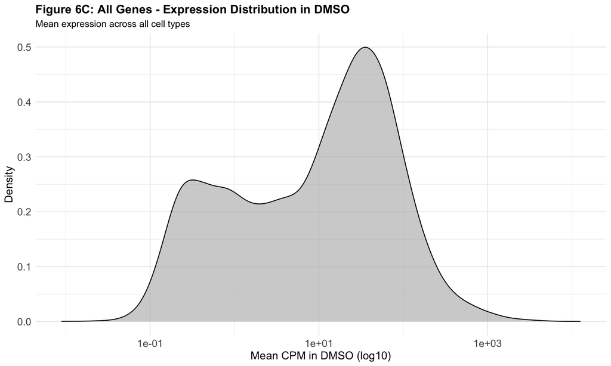

```r
if (has_condition_data) {
  # Calculate mean expression across all cell types for all genes in DMSO
  all_genes_dmso <- gene_expr_by_condition %>%
    filter(treatment == "DMSO", mean_cpm > 0) %>%
    group_by(gene_id, hgnc_symbol) %>%
    summarize(
      mean_cpm = mean(mean_cpm),
      .groups = "drop"
    )

  if (nrow(all_genes_dmso) > 0) {
    ggplot(all_genes_dmso, aes(x = mean_cpm)) +
      geom_density(fill = "gray70", alpha = 0.6) +
      scale_x_log10() +
      labs(
        title = "Figure 6C: All Genes - Expression Distribution in DMSO",
        subtitle = "Mean expression across all cell types",
        x = "Mean CPM in DMSO (log10)",
        y = "Density"
      ) +
      theme_minimal() +
      theme(
        axis.text = element_text(size = 12),
        axis.title = element_text(size = 13),
        plot.title = element_text(size = 14, face = "bold"),
        plot.subtitle = element_text(size = 11)
      )
  } else {
    cat("No data available for Figure 6C\n")
  }
} else {
  cat("Condition-specific data not available\n")
}
```

### 8.1.4 NMD-Responsive Genes: Expression in DMSO

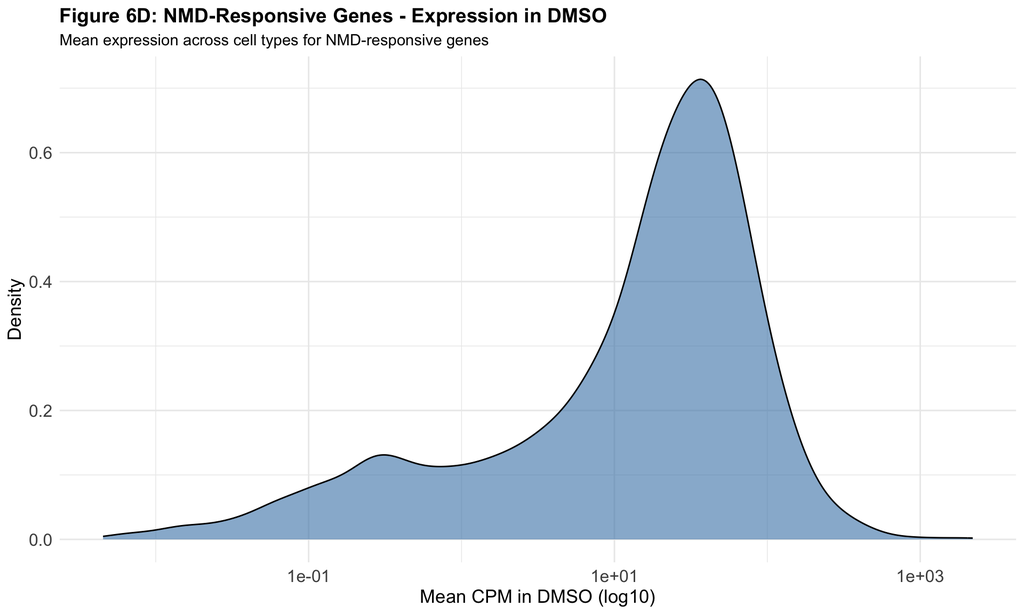

```r
if (has_condition_data) {
  # Get NMD-responsive genes with their DMSO expression
  nmd_genes_dmso <- gene_expr_by_condition %>%
    filter(treatment == "DMSO") %>%
    inner_join(
      nmd_responsive_genes %>%
        select(cell_type, ensembl_gene_id_version) %>%
        distinct(),
      by = c("cell_type", "gene_id" = "ensembl_gene_id_version")
    ) %>%
    group_by(gene_id, hgnc_symbol) %>%
    summarize(
      mean_cpm = mean(mean_cpm),
      .groups = "drop"
    ) %>%
    filter(mean_cpm > 0)

  if (nrow(nmd_genes_dmso) > 0) {
    ggplot(nmd_genes_dmso, aes(x = mean_cpm)) +
      geom_density(fill = "steelblue", alpha = 0.6) +
      scale_x_log10() +
      labs(
        title = "Figure 6D: NMD-Responsive Genes - Expression in DMSO",
        subtitle = "Mean expression across cell types for NMD-responsive genes",
        x = "Mean CPM in DMSO (log10)",
        y = "Density"
      ) +
      theme_minimal() +
      theme(
        axis.text = element_text(size = 12),
        axis.title = element_text(size = 13),
        plot.title = element_text(size = 14, face = "bold"),
        plot.subtitle = element_text(size = 11)
      )
  } else {
    cat("No data available for Figure 6D\n")
  }
} else {
  cat("Condition-specific data not available\n")
}
```

### 8.1.5 NMD-Responsive Genes: DMSO vs Smg1i Expression

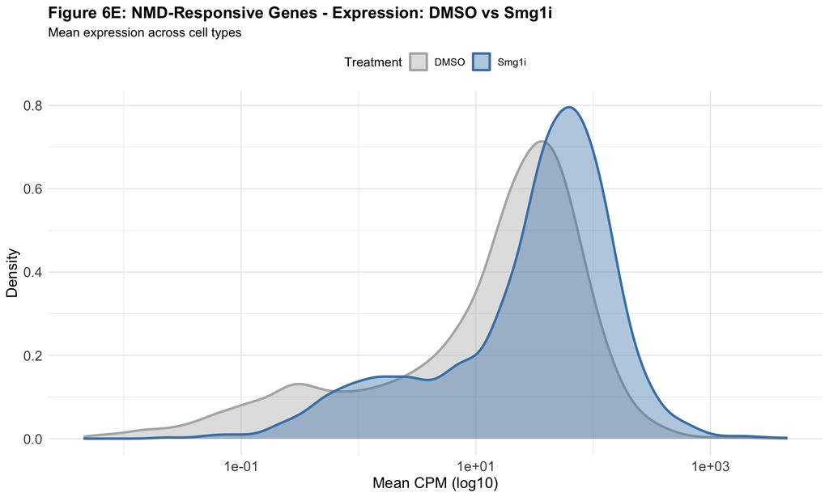

```r
if (has_condition_data) {
  # Get expression in both conditions for NMD-responsive genes
  nmd_genes_both <- gene_expr_by_condition %>%
    inner_join(
      nmd_responsive_genes %>%
        select(cell_type, ensembl_gene_id_version) %>%
        distinct(),
      by = c("cell_type", "gene_id" = "ensembl_gene_id_version")
    ) %>%
    group_by(gene_id, hgnc_symbol, treatment) %>%
    summarize(
      mean_cpm = mean(mean_cpm),
      .groups = "drop"
    ) %>%
    filter(mean_cpm > 0)

  if (nrow(nmd_genes_both) > 0) {
    ggplot(nmd_genes_both, aes(x = mean_cpm, fill = treatment, color = treatment)) +
      geom_density(alpha = 0.4, linewidth = 1) +
      scale_x_log10() +
      scale_fill_manual(values = c("DMSO" = "gray70", "Smg1i" = "steelblue")) +
      scale_color_manual(values = c("DMSO" = "gray70", "Smg1i" = "steelblue")) +
      labs(
        title = "Figure 6E: NMD-Responsive Genes - Expression: DMSO vs Smg1i",
        subtitle = "Mean expression across cell types",
        x = "Mean CPM (log10)",
        y = "Density",
        fill = "Treatment",
        color = "Treatment"
      ) +
      theme_minimal() +
      theme(
        legend.position = "top",
        axis.text = element_text(size = 12),
        axis.title = element_text(size = 13),
        plot.title = element_text(size = 14, face = "bold"),
        plot.subtitle = element_text(size = 11)
      )
  } else {
    cat("No data available for Figure 6E\n")
  }
} else {
  cat("Condition-specific data not available\n")
}
```

## 8.2 Effect Size Analysis

```r
cat("\n## Distribution of fold changes for NMD-responsive genes\n\n")
```

```
##
## ## Distribution of fold changes for NMD-responsive genes
```

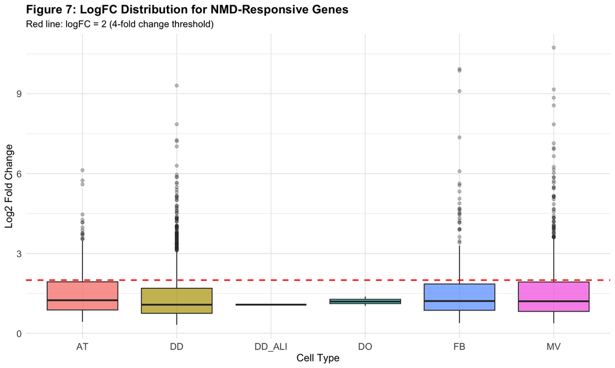

```r
# Boxplot of logFC
ggplot(nmd_responsive_genes, aes(x = cell_type, y = logFC, fill = cell_type)) +
  geom_boxplot(alpha = 0.7, outlier.alpha = 0.3) +
  geom_hline(yintercept = 2, linetype = "dashed", color = "red", linewidth = 0.8) +
  labs(
    title = "Figure 7: LogFC Distribution for NMD-Responsive Genes",
    subtitle = "Red line: logFC = 2 (4-fold change threshold)",
    x = "Cell Type",
    y = "Log2 Fold Change",
    fill = "Cell Type"
  ) +
  theme_minimal() +
  theme(
    legend.position = "none",
    axis.text = element_text(size = 11),
    axis.title = element_text(size = 12),
    plot.title = element_text(size = 14, face = "bold")
  )
```

```r
# Identify genes with extreme fold changes
extreme_fc_genes <- nmd_responsive_genes %>%
  filter(abs(logFC) > 2) %>%
  arrange(desc(logFC))

cat("\n**Table 12. Genes with extreme fold changes (|logFC| > 2):**", nrow(extreme_fc_genes), "genes\n\n")
```

```
##
## **Table 12. Genes with extreme fold changes (|logFC| > 2):** 929 genes
```

```r
extreme_fc_summary <- extreme_fc_genes %>%
  group_by(cell_type) %>%
  summarize(n_extreme = n(), .groups = "drop")

print(extreme_fc_summary)
```

```
## # A tibble: 4 × 2
##   cell_type n_extreme
##   <chr>         <int>
## 1 AT              143
## 2 DD              395
## 3 FB              117
## 4 MV              274
```

```r
cat("\n")
```

## 8.3 Expression vs Fold Change Relationship

```r
cat("## Relationship between baseline expression and fold change\n\n")
```

```
## ## Relationship between baseline expression and fold change
```

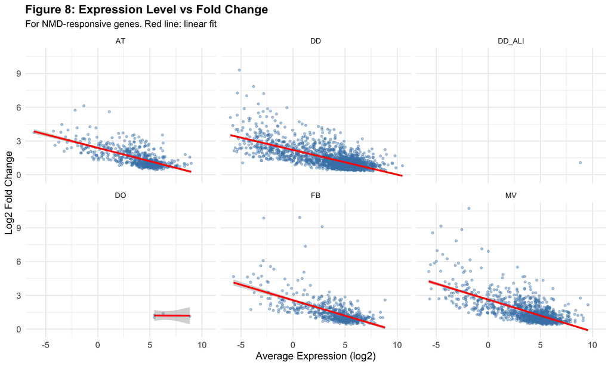

```r
# Scatter plot with trend line
ggplot(nmd_responsive_genes, aes(x = AveExpr, y = logFC)) +
  geom_point(alpha = 0.4, size = 1, color = "steelblue") +
  geom_smooth(method = "lm", se = TRUE, color = "red", linewidth = 1) +
  facet_wrap(~cell_type, ncol = 3) +
  labs(
    title = "Figure 8: Expression Level vs Fold Change",
    subtitle = "For NMD-responsive genes. Red line: linear fit",
    x = "Average Expression (log2)",
    y = "Log2 Fold Change"
  ) +
  theme_minimal() +
  theme(
    axis.text = element_text(size = 10),
    axis.title = element_text(size = 12),
    plot.title = element_text(size = 14, face = "bold")
  )
```

```r
# Calculate correlation
correlation_results <- nmd_responsive_genes %>%
  group_by(cell_type) %>%
  summarize(
    n_genes = n(),
    correlation = ifelse(n() >= 3, cor(AveExpr, logFC, method = "pearson", use = "complete.obs"), NA_real_),
    p_value = ifelse(n() >= 3,
                     tryCatch(cor.test(AveExpr, logFC)$p.value, error = function(e) NA_real_),
                     NA_real_),
    .groups = "drop"
  )

cat("\n**Table 13. Correlation between expression level and fold change:**\n\n")
```

```
##
## **Table 13. Correlation between expression level and fold change:**
```

```r
print(correlation_results)
```

```
## # A tibble: 6 × 4
##   cell_type n_genes correlation    p_value
##   <chr>       <int>       <dbl>      <dbl>
## 1 AT            603     -0.675   1.97e- 81
## 2 DD           2085     -0.701   2.05e-308
## 3 DD_ALI          1     NA      NA
## 4 DO              4     -0.0425  9.58e-  1
## 5 FB            573     -0.633   2.14e- 65
## 6 MV           1198     -0.676   1.26e-160
```

```r
cat("\n")
```

```r
# Save characteristics data
characteristics_data <- nmd_responsive_genes %>%
  select(cell_type, ensembl_gene_id_version, hgnc_symbol, gene_display,
         logFC, adj.P.Val, AveExpr) %>%
  mutate(extreme_fc = abs(logFC) > 2)

write_tsv(characteristics_data, OUTPUT_CHARACTERISTICS)
cat("Saved:", OUTPUT_CHARACTERISTICS, "\n\n")
```

```
## Saved: ../tmp/gene_characteristics_2026.1.15.tsv
```

# 9 GSEA: Pathway Enrichment Analysis

## 9.1 Load Gene Sets

```r
cat("## Loading MSigDB gene sets for GSEA\n\n")
```

```
## ## Loading MSigDB gene sets for GSEA
```

```r
# Set CRAN mirror
options(repos = c(CRAN = "https://cloud.r-project.org"))

# Load GSEA libraries
if (!require("fgsea", quietly = TRUE)) {
  if (!require("BiocManager", quietly = TRUE)) {
    install.packages("BiocManager")
  }
  BiocManager::install("fgsea")
  library(fgsea)
}

if (!require("msigdbr", quietly = TRUE)) {
  install.packages("msigdbr")
  library(msigdbr)
}

library(fgsea)
library(msigdbr)

# GSEA parameters
GSEA_MIN_SIZE <- 15
GSEA_MAX_SIZE <- 500
GSEA_NPERM <- 10000
GSEA_FDR_THRESHOLD <- 0.05

cat("GSEA Parameters:\n")
```

```
## GSEA Parameters:
```

```r
cat("- Pathway size:", GSEA_MIN_SIZE, "-", GSEA_MAX_SIZE, "genes\n")
```

```
## - Pathway size: 15 - 500 genes
```

```r
cat("- Permutations:", GSEA_NPERM, "\n")
```

```
## - Permutations: 10000
```

```r
cat("- Significance threshold: FDR <", GSEA_FDR_THRESHOLD, "\n\n")
```

```
## - Significance threshold: FDR < 0.05
```

```r
# Load MSigDB gene sets
cat("Loading Hallmark gene sets...\n")
```

```
## Loading Hallmark gene sets...
```

```r
msigdb_h <- msigdbr(species = "Homo sapiens", category = "H")

cat("Loading GO Biological Process gene sets...\n")
```

```
## Loading GO Biological Process gene sets...
```

```r
msigdb_bp <- msigdbr(species = "Homo sapiens", category = "C5", subcategory = "GO:BP")

cat("Loading KEGG gene sets...\n")
```

```
## Loading KEGG gene sets...
```

```r
msigdb_kegg <- msigdbr(species = "Homo sapiens", category = "C2", subcategory = "CP:KEGG_LEGACY")

cat("Loading Reactome gene sets...\n")
```

```
## Loading Reactome gene sets...
```

```r
msigdb_reactome <- msigdbr(species = "Homo sapiens", category = "C2", subcategory = "CP:REACTOME")

# Combine all gene sets
all_genesets <- bind_rows(
  msigdb_h %>% mutate(collection = "Hallmark"),
  msigdb_bp %>% mutate(collection = "GO_BP"),
  msigdb_kegg %>% mutate(collection = "KEGG"),
  msigdb_reactome %>% mutate(collection = "Reactome")
)

cat("\nGene set summary:\n")
```

```
##
## Gene set summary:
```

```r
geneset_summary <- all_genesets %>%
  group_by(collection) %>%
  summarize(
    n_genesets = n_distinct(gs_name),
    n_genes = n_distinct(gene_symbol),
    .groups = "drop"
  )
print(geneset_summary)
```

```
## # A tibble: 4 × 3
##   collection n_genesets n_genes
##   <chr>           <int>   <int>
## 1 GO_BP            7583   18000
## 2 Hallmark           50    4384
## 3 KEGG              186    5245
## 4 Reactome         1787   11369
```

```r
# Convert to fgsea format
pathways <- all_genesets %>%
  split(x = .$gene_symbol, f = .$gs_name)

# Filter by size
pathways_filtered <- pathways[
  sapply(pathways, length) >= GSEA_MIN_SIZE &
  sapply(pathways, length) <= GSEA_MAX_SIZE
]

cat("\nTotal pathways before filtering:", length(pathways), "\n")
```

```
##
## Total pathways before filtering: 9606
```

```r
cat("Pathways after size filtering:", length(pathways_filtered), "\n\n")
```

```
## Pathways after size filtering: 5632
```

## 9.2 Prepare Gene Rankings

```r
cat("## Preparing gene-level rankings for GSEA\n\n")
```

```
## ## Preparing gene-level rankings for GSEA
```

```r
cat("**Ranking strategy:**\n")
```

```
## **Ranking strategy:**
```

```r
cat("- Rank ALL genes by logFC (not just significant ones)\n")
```

```
## - Rank ALL genes by logFC (not just significant ones)
```

```r
cat("- Use valid HGNC gene symbols for matching with MSigDB pathways\n")
```

```
## - Use valid HGNC gene symbols for matching with MSigDB pathways
```

```r
cat("- This captures the full distribution of NMD effects\n\n")
```

```
## - This captures the full distribution of NMD effects
```

```r
# Create rankings per cell type
rankings_per_celltype <- list()

for (ct in unique(all_gene_dge$cell_type)) {
  cat("Preparing ranked list for", ct, "...\n")

  # Get all genes with valid symbols for this cell type
  # Handle duplicates by keeping the gene with the best (lowest) P.Value
  # Use P.Value instead of adj.P.Val to minimize ties
  ranked_data <- all_gene_dge %>%
    filter(cell_type == ct, valid_symbol) %>%
    group_by(hgnc_symbol) %>%
    slice_min(order_by = P.Value, n = 1, with_ties = FALSE) %>%
    ungroup() %>%
    arrange(desc(logFC))

  # Create named vector for GSEA
  ranked_vector <- setNames(ranked_data$logFC, ranked_data$hgnc_symbol)

  rankings_per_celltype[[ct]] <- ranked_vector

  cat("  Genes in ranked list:", length(ranked_vector), "\n")
  cat("  Unique gene symbols:", n_distinct(ranked_data$hgnc_symbol), "\n")
  cat("  Genes with logFC > 0:", sum(ranked_data$logFC > 0), "\n")
  cat("  Range:", round(min(ranked_data$logFC), 2), "to", round(max(ranked_data$logFC), 2), "\n\n")
}
```

```
## Preparing ranked list for AT ...
##   Genes in ranked list: 18099
##   Unique gene symbols: 18099
##   Genes with logFC > 0: 7628
##   Range: -6.14 to 6.43
##
## Preparing ranked list for DD ...
##   Genes in ranked list: 18099
##   Unique gene symbols: 18099
##   Genes with logFC > 0: 8828
##   Range: -4.74 to 9.31
##
## Preparing ranked list for DD_ALI ...
##   Genes in ranked list: 18099
##   Unique gene symbols: 18099
##   Genes with logFC > 0: 7677
##   Range: -5.73 to 6.19
##
## Preparing ranked list for DO ...
##   Genes in ranked list: 18099
##   Unique gene symbols: 18099
##   Genes with logFC > 0: 7696
##   Range: -6.63 to 7.21
##
## Preparing ranked list for FB ...
##   Genes in ranked list: 18099
##   Unique gene symbols: 18099
##   Genes with logFC > 0: 7954
##   Range: -7.08 to 9.1
##
## Preparing ranked list for MV ...
##   Genes in ranked list: 18099
##   Unique gene symbols: 18099
##   Genes with logFC > 0: 7775
##   Range: -8.14 to 10.73
```

## 9.3 Run GSEA

```r
cat("## Running GSEA Per Cell Type\n\n")
```

## 9.4 Running GSEA Per Cell Type

```r
library(htmltools)

gsea_results_all <- list()
table_num <- 14  # Continue numbering after Table 13

for (ct in names(rankings_per_celltype)) {
  cat("### ", ct, "\n\n")

  ranked_list <- rankings_per_celltype[[ct]]

  cat("Running fgsea with", GSEA_NPERM, "permutations...\n\n")

  gsea_res <- fgsea(
    pathways = pathways_filtered,
    stats = ranked_list,
    minSize = GSEA_MIN_SIZE,
    maxSize = GSEA_MAX_SIZE,
    nperm = GSEA_NPERM
  )

  gsea_res$cell_type <- ct
  gsea_results_all[[ct]] <- gsea_res

  # Summary
  sig_pathways <- sum(gsea_res$padj < GSEA_FDR_THRESHOLD, na.rm = TRUE)
  cat("Pathways with FDR <", GSEA_FDR_THRESHOLD, ":", sig_pathways, "\n\n")

  # Display top 100 results
  top_100 <- gsea_res %>%
    arrange(pval) %>%
    head(100) %>%
    select(pathway, pval, padj, ES, NES, size, leadingEdge) %>%
    mutate(
      pathway_short = str_trunc(pathway, 60),
      leadingEdge = sapply(leadingEdge, function(x) paste(head(x, 5), collapse = ", "))
    ) %>%
    select(pathway_short, pval, padj, ES, NES, size, leadingEdge)

  cat("**Table", table_num, ". Top 100 GSEA Results for", ct, "**\n\n")

  dt <- datatable(
    top_100,
    options = list(
      pageLength = 10,
      scrollX = TRUE
    ),
    caption = paste0("Top 100 GSEA results for ", ct, " (ranked by p-value)")
  ) %>%
    formatRound(columns = c("pval", "padj", "ES", "NES"), digits = 4)

  print(htmltools::tagList(dt))
  cat("\n\n")

  table_num <- table_num + 1
}
```

### 9.4.1 AT

Running fgsea with 10000 permutations…

Pathways with FDR < 0.05 : 133

**Table 14 . Top 100 GSEA Results for AT**

|  | pathway_short | pval | padj | ES | NES | size | leadingEdge |
| --- | --- | --- | --- | --- | --- | --- | --- |
| 1 | GOBP_TRNA_METABOLIC_PROCESS | 0.0001421060110842689 | 0.04401914699450729 | 0.4540620770207708 | 1.805864224664092 | 200 | TYW5, TRMT10B, THUMPD2, CARS1, WDR4 |
| 2 | GOBP_TRNA_MODIFICATION | 0.0001558846453624318 | 0.04401914699450729 | 0.5499338569303113 | 1.978941978279222 | 93 | TYW5, TRMT10B, THUMPD2, WDR4, TYW1B |
| 3 | GOBP_CARDIAC_EPITHELIAL_TO_MESENCHYMAL_TRANSITION | 0.0002357934449422306 | 0.04401914699450729 | -0.6357047893203495 | -2.06332865277553 | 36 | TMEM100, MSX1, HAS2, HEY2, ACVRL1 |
| 4 | REACTOME_SARS_COV_1_MODULATES_HOST_TRANSLATION_MACHINERY | 0.0002357934449422306 | 0.04401914699450729 | -0.6291867353152854 | -2.042172783235259 | 36 | RPS4Y1, RPS29, RPS14, RPS21, RPS3 |
| 5 | REACTOME_SARS_COV_2_MODULATES_HOST_TRANSLATION_MACHINERY | 0.0002498126405196103 | 0.04401914699450729 | -0.5708994032895248 | -1.980539325763025 | 50 | RPS4Y1, RPS29, RPS14, RPS21, RPS3 |
| 6 | GOBP_NEURON_FATE_COMMITMENT | 0.0002520161290322581 | 0.04401914699450729 | -0.5463646267698511 | -1.912889252458245 | 52 | GATA2, MNX1, SOX9, EPOP, GLI3 |
| 7 | GOBP_POSITIVE_REGULATION_OF_MIRNA_TRANSCRIPTION | 0.0002533569799847986 | 0.04401914699450729 | -0.5448294096659481 | -1.915636170153447 | 53 | APLN, GATA2, IL10, MYOCD, FOS |
| 8 | GOBP_VASOCONSTRICTION | 0.0002641310089804543 | 0.04401914699450729 | -0.5181637101010466 | -1.922667445028697 | 70 | APLN, LEP, AVPR1A, SLC8A1, ADM |
| 9 | GOBP_CARDIAC_SEPTUM_MORPHOGENESIS | 0.0002657454158915759 | 0.04401914699450729 | -0.5716055781861532 | -2.131946192402165 | 72 | LRP2, EGLN1, FZD2, HEY2, DHRS3 |
| 10 | GOBP_MIRNA_TRANSCRIPTION | 0.0002657454158915759 | 0.04401914699450729 | -0.5237708589503335 | -1.953534624301231 | 72 | APLN, NFATC4, GATA2, SOX9, POU5F1 |

[output cut: 90 more lines]

### 9.4.2 DD

Running fgsea with 10000 permutations…

Pathways with FDR < 0.05 : 90

**Table 15 . Top 100 GSEA Results for DD**

|  | pathway_short | pval | padj | ES | NES | size | leadingEdge |
| --- | --- | --- | --- | --- | --- | --- | --- |
| 1 | GOBP_MICROTUBULE_BASED_MOVEMENT | 0.0001019887812340643 | 0.04944396093221158 | 0.4068939036694154 | 1.649048431877702 | 435 | DNAH17, DNAH6, TEKT3, NEK10, CFAP47 |
| 2 | GOBP_CALCIUM_ION_TRANSMEMBRANE_TRANSPORT | 0.0001059883412824589 | 0.04944396093221158 | 0.4059390317018374 | 1.598713092745989 | 263 | PKD1L1, DDIT3, RYR3, CACNB1, BHLHA15 |
| 3 | GOBP_CILIUM_MOVEMENT | 0.0001082133968185261 | 0.04944396093221158 | 0.5096040306734388 | 1.97551257175233 | 213 | DNAH17, DNAH6, TEKT3, NEK10, CFAP47 |
| 4 | GOBP_CILIUM_OR_FLAGELLUM_DEPENDENT_CELL_MOTILITY | 0.0001114454474534715 | 0.04944396093221158 | 0.5186621695515392 | 1.969972043853166 | 171 | DNAH17, DNAH6, TEKT3, CFAP47, CCDC146 |
| 5 | GOBP_GOLGI_ORGANIZATION | 0.0001140901312036509 | 0.04944396093221158 | 0.4666386815239417 | 1.740638394428414 | 145 | GOLGA8K, BHLHA15, FBXW8, DYNC2H1, LRRK2 |
| 6 | GOBP_PROTEIN_AUTOPHOSPHORYLATION | 0.0001152472052552726 | 0.04944396093221158 | 0.4955699037316698 | 1.831012654125622 | 130 | NEK10, DDR2, MAK, ALK, FLT4 |
| 7 | GOBP_CELLULAR_RESPONSE_TO_TOPOLOGICALLY_INCORRECT_PROTEIN | 0.0001176055509820064 | 0.04944396093221158 | 0.4726293648236497 | 1.718285556251778 | 114 | DDIT3, HERPUD1, BHLHA15, HSPA1A, ATF4 |
| 8 | GOBP_CELLULAR_COMPONENT_ASSEMBLY_INVOLVED_IN_MORPHOGENESIS | 0.0001190759704691593 | 0.04944396093221158 | 0.4876045920271539 | 1.752801876880004 | 105 | ACTN2, SYNPO2L, ANK2, TMOD1, MYLK3 |
| 9 | GOBP_AXONEME_ASSEMBLY | 0.0001200192030724916 | 0.04944396093221158 | 0.4936072816684657 | 1.761226987582236 | 98 | DNAH17, CFAP47, CCDC146, DRC1, CFAP69 |
| 10 | GOBP_CELLULAR_RESPONSE_TO_UNFOLDED_PROTEIN | 0.0001200192030724916 | 0.04944396093221158 | 0.4929324959386754 | 1.759796977999029 | 99 | DDIT3, HERPUD1, BHLHA15, HSPA1A, ATF4 |

[output cut: 90 more lines]

### 9.4.3 DD_ALI

Running fgsea with 10000 permutations…

Pathways with FDR < 0.05 : 0

**Table 16 . Top 100 GSEA Results for DD_ALI**

|  | pathway_short | pval | padj | ES | NES | size | leadingEdge |
| --- | --- | --- | --- | --- | --- | --- | --- |
| 1 | REACTOME_NEURONAL_SYSTEM | 0.000181257930034439 | 0.2465284474445516 | -0.4625742350317419 | -1.704237252239839 | 320 | SLC1A2, TUBB1, KCNN1, KCNH1, GRIN2A |
| 2 | GOBP_LEARNING | 0.0001859773107680863 | 0.2465284474445516 | -0.5461949779682789 | -1.829222524326425 | 132 | GRIN2A, CLSTN2, SLC12A5, SLC6A1, NTSR1 |
| 3 | GOBP_ASSOCIATIVE_LEARNING | 0.0001874765654293213 | 0.2465284474445516 | -0.6068645551935762 | -1.887664514932412 | 77 | GRIN2A, CLSTN2, SLC6A1, NETO1, TAFA2 |
| 4 | GOBP_MODULATION_OF_EXCITATORY_POSTSYNAPTIC_POTENTIAL | 0.0001928640308582449 | 0.2465284474445516 | -0.6544540079128924 | -1.838182347183045 | 43 | GRIN2A, NETO1, NLGN1, GRIN1, GRIN2D |
| 5 | REACTOME_TRANSMISSION_ACROSS_CHEMICAL_SYNAPSES | 0.0003653635367190354 | 0.2676402847571189 | -0.4591115895690298 | -1.632562907110074 | 218 | SLC1A2, TUBB1, GRIN2A, KCNJ12, LRRC7 |
| 6 | GOBP_CENTRAL_NERVOUS_SYSTEM_NEURON_DIFFERENTIATION | 0.0003720238095238095 | 0.2676402847571189 | -0.4696117228536406 | -1.645071526534075 | 192 | POU3F2, TAL1, GBX2, ZEB2, LONRF2 |
| 7 | GOBP_NEUROMUSCULAR_SYNAPTIC_TRANSMISSION | 0.0003824823101931536 | 0.2676402847571189 | -0.7371395687107958 | -1.84499641341959 | 24 | RIMBP2, NLGN1, CHRNA5, RIMBP3, CHRNA1 |
| 8 | GOBP_CERAMIDE_METABOLIC_PROCESS | 0.000429000429000429 | 0.2676402847571189 | 0.5386629175822171 | 1.760839724168082 | 101 | GBA3, GAL3ST1, ST6GALNAC5, NEU4, B4GALNT1 |
| 9 | GOBP_COGNITION | 0.0005414185165132648 | 0.2676402847571189 | -0.419883390621742 | -1.52878608683403 | 273 | GRIN2A, CLSTN2, SLC12A5, KCNK2, SLC6A1 |
| 10 | KEGG_CELL_ADHESION_MOLECULES_CAMS | 0.0005647590361445783 | 0.2676402847571189 | -0.5473037053918468 | -1.80079536273547 | 115 | ITGA4, CDH5, NCAM2, VCAM1, ITGA9 |

[output cut: 90 more lines]

### 9.4.4 DO

Running fgsea with 10000 permutations…

Pathways with FDR < 0.05 : 0

**Table 17 . Top 100 GSEA Results for DO**

|  | pathway_short | pval | padj | ES | NES | size | leadingEdge |
| --- | --- | --- | --- | --- | --- | --- | --- |
| 1 | KEGG_RIBOSOME | 0.0002181025081788441 | 0.3041280038068047 | -0.602443661504563 | -1.987096129203245 | 85 | RPS3, RPS19, RPL4, RPL12, RPL36 |
| 2 | REACTOME_EUKARYOTIC_TRANSLATION_ELONGATION | 0.0002210433244916003 | 0.3041280038068047 | -0.6083936480699655 | -2.021834467292125 | 91 | EEF1A2, RPS3, RPS19, RPL4, RPL12 |
| 3 | GOBP_CELL_CELL_ADHESION_VIA_PLASMA_MEMBRANE_ADHESION_MOLE... | 0.0002355157795572303 | 0.3041280038068047 | -0.4458630753595055 | -1.688670770674584 | 240 | SLITRK5, L1CAM, PCDH17, CADM2, VCAM1 |
| 4 | GOBP_EXTERNAL_ENCAPSULATING_STRUCTURE_ORGANIZATION | 0.000237925291458482 | 0.3041280038068047 | -0.404001123980351 | -1.568501712593586 | 303 | COL4A3, COL5A1, RAMP2, OLFML2B, ADAMTS10 |
| 5 | GOBP_DOPAMINE_SECRETION | 0.0004180602006688963 | 0.3775995509866478 | -0.7518472040189901 | -1.91546313023547 | 22 | GNAT1, GDNF, SYT1, OPRK1, GRM2 |
| 6 | GOBP_HOMOPHILIC_CELL_ADHESION_VIA_PLASMA_MEMBRANE_ADHESIO... | 0.0004552697473252903 | 0.3775995509866478 | -0.4837208099731846 | -1.73077106591219 | 150 | L1CAM, PCDH17, CADM2, FAT3, PCDH18 |
| 7 | REACTOME_SRP_DEPENDENT_COTRANSLATIONAL_PROTEIN_TARGETING_... | 0.0006746120980436249 | 0.3775995509866478 | -0.528911948545661 | -1.809420649285731 | 110 | RPS3, RPS19, RPL4, RPL12, RPL36 |
| 8 | GOBP_SEX_DIFFERENTIATION | 0.0007095553453169347 | 0.3775995509866478 | -0.4011840375188746 | -1.522760112543546 | 245 | PTPRN, GATA4, TLR9, DACH2, BMP5 |
| 9 | GOBP_SPROUTING_ANGIOGENESIS | 0.0009031384059607134 | 0.3775995509866478 | -0.4777069950516453 | -1.681990450862141 | 134 | TSPAN18, CCBE1, RAMP2, MMRN1, TEK |
| 10 | GOBP_MUSCLE_CONTRACTION | 0.0009454029780193808 | 0.3775995509866478 | -0.3904159192047093 | -1.505306531541727 | 284 | KCNN2, GATA4, GDNF, PDE4B, SGCD |

[output cut: 90 more lines]

### 9.4.5 FB

Running fgsea with 10000 permutations…

Pathways with FDR < 0.05 : 0

**Table 18 . Top 100 GSEA Results for FB**

|  | pathway_short | pval | padj | ES | NES | size | leadingEdge |
| --- | --- | --- | --- | --- | --- | --- | --- |
| 1 | REACTOME_CARBOXYTERMINAL_POST_TRANSLATIONAL_MODIFICATIONS... | 0.0001696352841391009 | 0.06797575048525618 | 0.6276554001372271 | 1.984916312707516 | 41 | TUBA8, TUBB8, AGBL1, TTLL13, TUBB1 |
| 2 | GOBP_LONG_TERM_MEMORY | 0.0002351281448389372 | 0.06797575048525618 | -0.59050815155686 | -1.900168837584159 | 33 | RASGRF1, LCN2, DRD2, NTF4, ADCY8 |
| 3 | GOBP_VENTRICULAR_SEPTUM_MORPHOGENESIS | 0.0002447980416156671 | 0.06797575048525618 | -0.5489408482298475 | -1.871536830756671 | 43 | NOS3, MIR17HG, PROX1, VANGL2, FGFR2 |
| 4 | REACTOME_SARS_COV_2_MODULATES_HOST_TRANSLATION_MACHINERY | 0.0002537427048972342 | 0.06797575048525618 | -0.5752479260920148 | -2.021666521865079 | 50 | RPS27L, SNRPF, RPS23, SNRPD2, GEMIN6 |
| 5 | GOBP_REGULATION_OF_B_CELL_PROLIFERATION | 0.0002541942043721403 | 0.06797575048525618 | -0.5336008542742792 | -1.900809568062184 | 53 | CD38, CTLA4, WNT3A, CD22, LYN |
| 6 | KEGG_RIBOSOME | 0.0002670940170940171 | 0.06797575048525618 | -0.5460203419160922 | -2.128817218989226 | 85 | RPS27L, RPL41, RPL14, RPS23, RPL24 |
| 7 | REACTOME_EUKARYOTIC_TRANSLATION_ELONGATION | 0.000272108843537415 | 0.06797575048525618 | -0.5259821527830362 | -2.075944743036211 | 91 | RPS27L, RPL41, RPL14, RPS23, RPL24 |
| 8 | GOBP_ATP_SYNTHESIS_COUPLED_ELECTRON_TRANSPORT | 0.0002777006387114691 | 0.06797575048525618 | -0.4801400469664334 | -1.901905362219116 | 95 | NDUFC2-KCTD14, SDHD, NDUFC2, MTCO2P12, NDUFA3 |
| 9 | REACTOME_MITOCHONDRIAL_TRANSLATION | 0.0002777006387114691 | 0.06797575048525618 | -0.4505502583568415 | -1.784695856411226 | 95 | MRPS18C, MRPL55, MRPL35, MRPL50, MRPL36 |
| 10 | HALLMARK_INTERFERON_ALPHA_RESPONSE | 0.0002795638803466592 | 0.06797575048525618 | -0.4629314140765599 | -1.840424086953295 | 97 | IFI30, CCRL2, RTP4, IL7, LPAR6 |

[output cut: 90 more lines]

### 9.4.6 MV

Running fgsea with 10000 permutations…

Pathways with FDR < 0.05 : 0

**Table 19 . Top 100 GSEA Results for MV**

|  | pathway_short | pval | padj | ES | NES | size | leadingEdge |
| --- | --- | --- | --- | --- | --- | --- | --- |
| 1 | GOBP_REGULATION_OF_CARDIAC_MUSCLE_CONTRACTION_BY_CALCIUM_... | 0.0002056343820686819 | 0.1453341292174753 | -0.650972767536205 | -1.950497228727811 | 27 | JPH1, RYR2, ANK2, TNNI3, NOS1 |
| 2 | REACTOME_CHEMOKINE_RECEPTORS_BIND_CHEMOKINES | 0.0002058460271716756 | 0.1453341292174753 | -0.7028453376496713 | -2.142542227260429 | 29 | CCR4, CXCL10, CCL2, ACKR2, ACKR4 |
| 3 | HALLMARK_INTERFERON_ALPHA_RESPONSE | 0.0002264492753623188 | 0.1453341292174753 | -0.5673553046419856 | -2.185766484978943 | 97 | IFI30, RTP4, LPAR6, CXCL10, BATF2 |
| 4 | GOBP_HOMOPHILIC_CELL_ADHESION_VIA_PLASMA_MEMBRANE_ADHESIO... | 0.0002354048964218456 | 0.1453341292174753 | -0.4278225328294718 | -1.769451066226474 | 150 | CDH23, PCDHAC2, CADM2, FAT3, PCDHB3 |
| 5 | REACTOME_CLASS_A_1_RHODOPSIN_LIKE_RECEPTORS | 0.0002405002405002405 | 0.1453341292174753 | -0.4068966013386172 | -1.714259803445428 | 173 | MCHR1, GPR37L1, GPR39, C5AR2, TACR1 |
| 6 | GOBP_HUMORAL_IMMUNE_RESPONSE | 0.0002410219329959026 | 0.1453341292174753 | -0.3986129642746383 | -1.682036565922403 | 176 | EVPL, TNF, SERPING1, H2BC6, CXCL10 |
| 7 | HALLMARK_INTERFERON_GAMMA_RESPONSE | 0.0002413127413127413 | 0.1453341292174753 | -0.4631898574112736 | -1.975796250661851 | 188 | TNFAIP6, IFI30, LCP2, SERPING1, RTP4 |
| 8 | GOBP_CELL_CELL_ADHESION_VIA_PLASMA_MEMBRANE_ADHESION_MOLE... | 0.000248323814253787 | 0.1453341292174753 | -0.4383292088011418 | -1.924695410930642 | 240 | CDH23, FLRT3, PCDHAC2, CADM2, FAT3 |
| 9 | GOBP_LEUKOCYTE_PROLIFERATION | 0.000255819902788437 | 0.1453341292174753 | -0.3503007408489022 | -1.568795751078011 | 283 | NDP, IKZF3, SOX11, TACR1, LGALS9C |
| 10 | GOBP_NEGATIVE_REGULATION_OF_VIRAL_GENOME_REPLICATION | 0.0004219409282700422 | 0.1566866879137043 | -0.5739066623325192 | -1.932963248574196 | 46 | TNF, IFIT1, ZC3HAV1, TRIM6, APOBEC3H |

[output cut: 90 more lines]

```r
# Combine all results
gsea_combined <- bind_rows(gsea_results_all)

cat("\n## Overall GSEA Results\n\n")
```

## 9.5 Overall GSEA Results

```r
cat("- Cell types analyzed:", paste(unique(gsea_combined$cell_type), collapse = ", "), "\n")
```

- Cell types analyzed: AT, DD, DD_ALI, DO, FB, MV

```r
cat("- Total pathways tested:", n_distinct(gsea_combined$pathway), "\n")
```

- Total pathways tested: 5113

```r
cat("- Total significant results (FDR <", GSEA_FDR_THRESHOLD, "):",
    sum(gsea_combined$padj < GSEA_FDR_THRESHOLD, na.rm = TRUE), "\n\n")
```

- Total significant results (FDR < 0.05 ): 223

```r
# Save results
write_tsv(gsea_combined, OUTPUT_GSEA_ALL)
cat("Saved all GSEA results:", OUTPUT_GSEA_ALL, "\n")
```

Saved all GSEA results: ../tmp/gene_gsea_results_2026.1.15.tsv

```r
# Save significant results
gsea_significant <- gsea_combined %>%
  filter(padj < GSEA_FDR_THRESHOLD) %>%
  arrange(padj)

if (nrow(gsea_significant) > 0) {
  write_tsv(gsea_significant, OUTPUT_GSEA_SIG)
  cat("Saved significant GSEA results:", OUTPUT_GSEA_SIG, "\n\n")
}
```

Saved significant GSEA results: ../tmp/gene_gsea_significant_2026.1.15.tsv

## 9.6 Cross-Cell-Type Pathway Analysis

```r
if (nrow(gsea_significant) > 0) {
  cat("## Pathways Consistent Across Cell Types\n\n")

  # Find pathways significant in multiple cell types
  pathway_counts <- gsea_significant %>%
    count(pathway) %>%
    arrange(desc(n)) %>%
    filter(n > 1)

  cat("Pathways significant in multiple cell types:", nrow(pathway_counts), "\n\n")

  if (nrow(pathway_counts) > 0) {
    cat("**Table 20. Top pathways by consistency:**\n\n")
    datatable(
      pathway_counts %>% head(20),
      options = list(pageLength = 10, scrollX = TRUE),
      caption = "Table 20. Pathways significant in multiple cell types"
    )

    # Show details for most consistent pathways
    cat("\n**Details for top consistent pathways:**\n\n")
    top_consistent <- pathway_counts %>% head(5) %>% pull(pathway)

    for (pw in top_consistent) {
      cat("\n**", pw, "**\n\n")
      pw_details <- gsea_significant %>%
        filter(pathway == pw) %>%
        select(cell_type, NES, padj) %>%
        arrange(cell_type)
      print(knitr::kable(pw_details, digits = 4))
    }
  }
} else {
  cat("## Cross-Cell-Type Pathway Analysis\n\n")
  cat("No significant pathways found (FDR < ", GSEA_FDR_THRESHOLD, ")\n\n")
}
```

[output not shown]

# 10 Key Findings

```r
cat("\n## Summary of Key Findings\n\n")
```

```
##
## ## Summary of Key Findings
```

```r
cat("**Gene-Level NMD Response:**\n")
```

```
## **Gene-Level NMD Response:**
```

```r
cat("- Average", round(mean(summary_stats$n_nmd_responsive)),
    "genes per cell type are NMD-responsive (",
    round(mean(summary_stats$pct_nmd_responsive), 1), "% of tested genes)\n")
```

```
## - Average 744 genes per cell type are NMD-responsive ( 83.5 % of tested genes)
```

```r
cat("- Mean logFC for NMD-responsive genes:",
    round(mean(summary_stats$mean_logFC_responsive), 2), "\n")
```

```
## - Mean logFC for NMD-responsive genes: 1.37
```

```r
cat("- Median logFC:", round(mean(summary_stats$median_logFC_responsive), 2), "\n\n")
```

```
## - Median logFC: 1.17
```

```r
cat("**Cell-Type Consistency:**\n")
```

```
## **Cell-Type Consistency:**
```

```r
cat("- Unique NMD-responsive genes across all cell types:",
    n_distinct(nmd_responsive_genes$ensembl_gene_id_version), "\n")
```

```
## - Unique NMD-responsive genes across all cell types: 2491
```

```r
if (exists("core_targets") && nrow(core_targets) > 0) {
  cat("- Core NMD targets (≥4 cell types):", nrow(core_targets), "genes\n")
}
```

```
## - Core NMD targets (≥4 cell types): 283 genes
```

```r
if (exists("celltype_specific") && nrow(celltype_specific) > 0) {
  cat("- Cell-type specific genes (1 cell type only):", nrow(celltype_specific), "genes\n")
}
```

```
## - Cell-type specific genes (1 cell type only): 1378 genes
```

```r
cat("\n")
```

```r
cat("**Gene Characteristics:**\n")
```

```
## **Gene Characteristics:**
```

```r
if (exists("extreme_fc_genes")) {
  cat("- Genes with extreme fold changes (|logFC| > 2):", nrow(extreme_fc_genes), "\n")
}
```

```
## - Genes with extreme fold changes (|logFC| > 2): 929
```

```r
cat("- Expression-fold change correlation: varies by cell type\n")
```

[output not shown]

```r
cat("  (see correlation table above for details)\n\n")
```

```
##   (see correlation table above for details)
```

```r
if (exists("gsea_significant") && nrow(gsea_significant) > 0) {
  cat("**GSEA - Pathway Enrichment:**\n")
  cat("- Total significant pathway enrichments:", nrow(gsea_significant), "\n")
  cat("- Pathways with high NMD effect identified across cell types\n")
  cat("- See GSEA section for detailed pathway analysis\n\n")
} else {
  cat("**GSEA - Pathway Enrichment:**\n")
  cat("- No pathways reached significance threshold\n")
  cat("- NMD-responsive genes may be broadly distributed across pathways\n\n")
}
```

[output not shown]